# examples_0415

$$A=\frac{7\cdot 5}{2}$$

You should be able to see it is half the area of the surrounding rectangle...

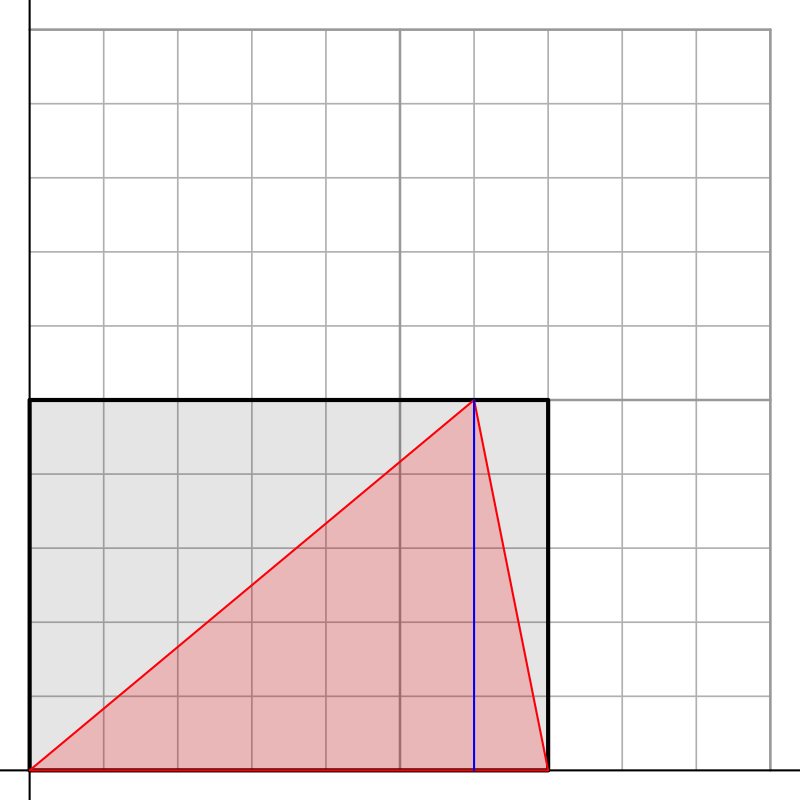

A triangle has vertices at $(0,0)$ and $(6,0)$ and $(3,7)$. Find the area (in square units).

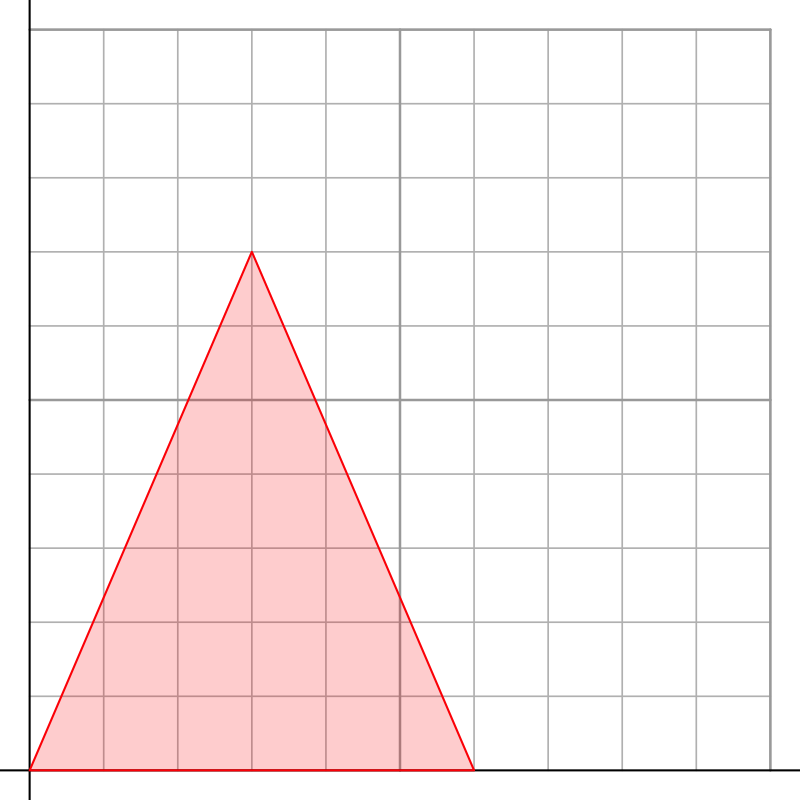

The area of a triangle is half the base times the height.

$$A=\frac{6\cdot 7}{2}$$

You should be able to see it is half the area of the surrounding rectangle...

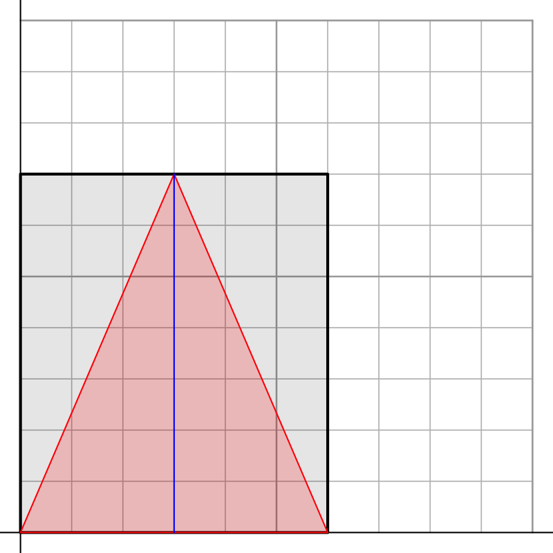

A triangle has vertices at $(0,0)$ and $(3,0)$ and $(1,8)$. Find the area (in square units).

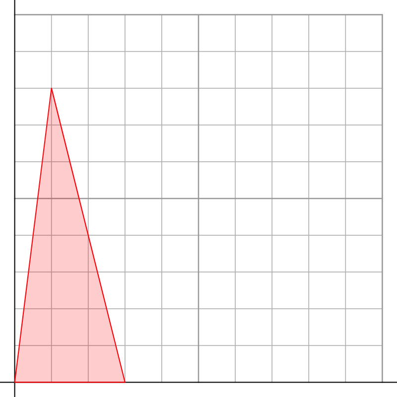

The area of a triangle is half the base times the height.

$$A=\frac{3\cdot 8}{2}$$

You should be able to see it is half the area of the surrounding rectangle...

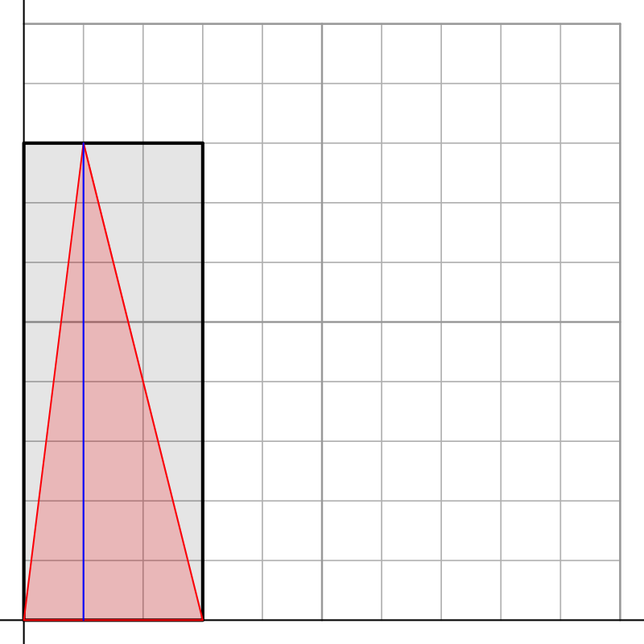

A triangle has vertices at $(0,0)$ and $(6,0)$ and $(1,6)$. Find the area (in square units).

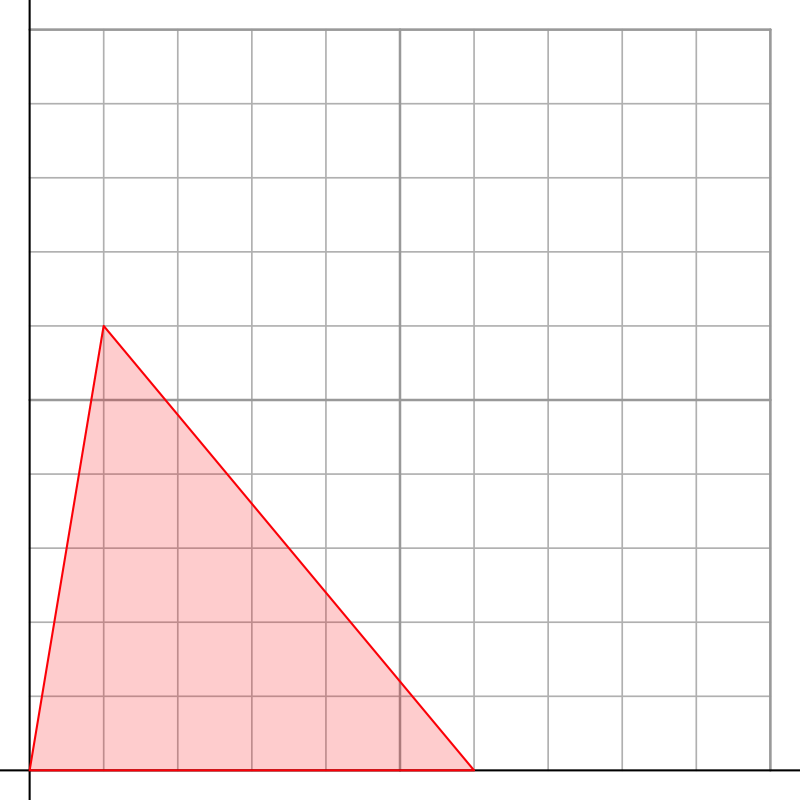

The area of a triangle is half the base times the height.

$$A=\frac{6\cdot 6}{2}$$

You should be able to see it is half the area of the surrounding rectangle...

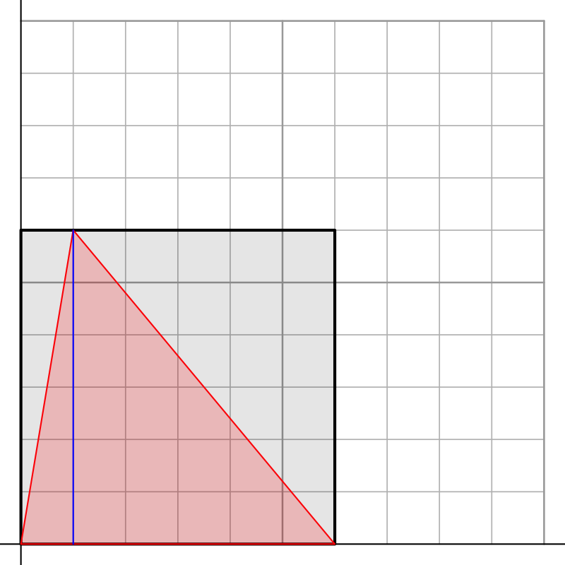

A triangle has vertices at $(0,0)$ and $(8,0)$ and $(7,5)$. Find the area (in square units).

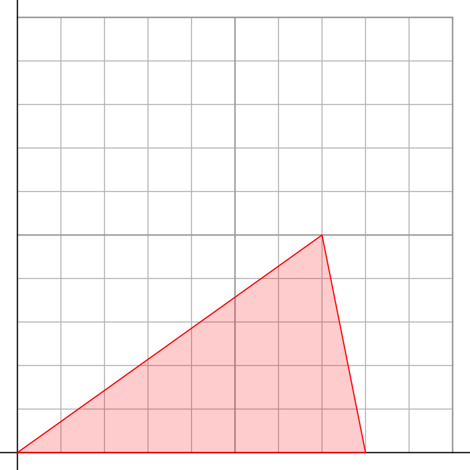

The area of a triangle is half the base times the height.

$$A=\frac{8\cdot 5}{2}$$

You should be able to see it is half the area of the surrounding rectangle...

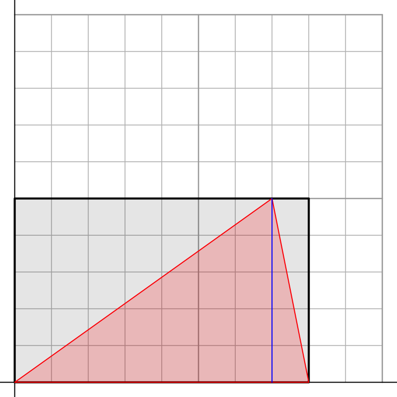

The [2D distance formula](https://en.wikipedia.org/wiki/Euclidean_distance#Two_dimensions) is an equivalent equation to the [Pythagorean equation](https://en.wikipedia.org/wiki/Pythagorean_theorem). When finding distance between two points on an $xy$-plane, it can be helpful to imagine a [right triangle](https://en.wikipedia.org/wiki/Right_triangle) with its legs horizontal and vertical, and its hypotenuse connecting the points. The length of the hypotenuse is the square root of the sum of the squares of the legs' lengths. Each leg's length is found by taking an absolute difference corresponding coordinates; for example $|x_2-x_1|$ is the length of the horizontal leg, and $|y_2-y_1|$ is the length of the vertical leg.

A square field is 200 feet by 200 feet. The field is marked with a grid pattern, so the Southwest corner is at point $(0,0)$ and the Northeast corner is at point $(200,200)$. Near the middle, at position $(91, 93)$ is a beacon, marked as a large bright-red dot. On the field are 5 players; their positions are listed in the table below. Find how far each player is from the beacon.

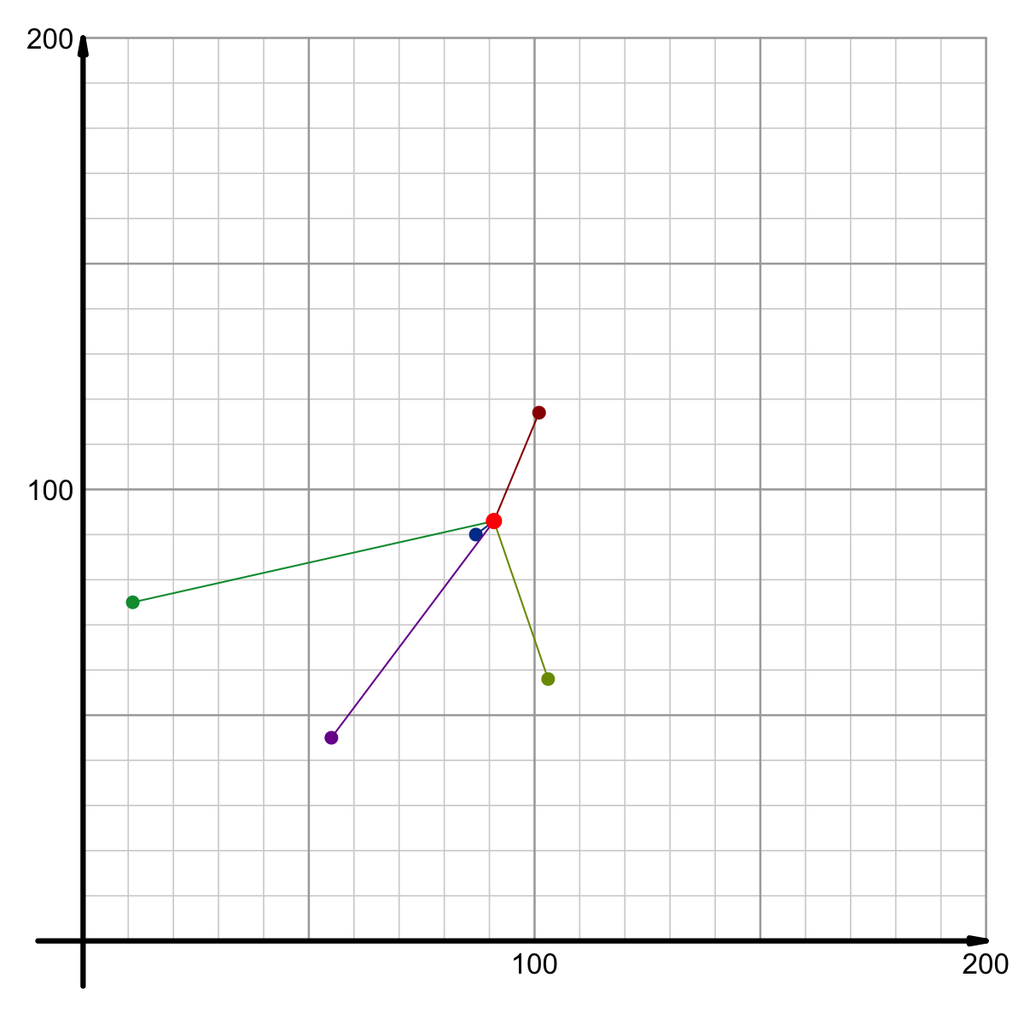

I would recommend setting this up in Desmos using $d=\sqrt{(x_2-91)^2+(y_2-93)^2}$ and using sliders for $x_2$ and $y_2$.

| Player | Position | Distance to beacon (ft) |
| --- | --- | --- |
| 1 | (101,117) |  |
| 2 | (103,58) |  |
| 3 | (11,75) |  |
| 4 | (87,90) |  |
| 5 | (55,45) |  |

I would recommend setting this up in Desmos using $d=\sqrt{(x_2-91)^2+(y_2-93)^2}$ and using sliders for $x_2$ and $y_2$.

$$\sqrt{(101-91)^2+(117-93)^2}~=~26$$

$$\sqrt{(103-91)^2+(58-93)^2}~=~37$$

$$\sqrt{(11-91)^2+(75-93)^2}~=~82$$

$$\sqrt{(87-91)^2+(90-93)^2}~=~5$$

$$\sqrt{(55-91)^2+(45-93)^2}~=~60$$

The [2D distance formula](https://en.wikipedia.org/wiki/Euclidean_distance#Two_dimensions) is an equivalent equation to the [Pythagorean equation](https://en.wikipedia.org/wiki/Pythagorean_theorem). When finding distance between two points on an $xy$-plane, it can be helpful to imagine a [right triangle](https://en.wikipedia.org/wiki/Right_triangle) with its legs horizontal and vertical, and its hypotenuse connecting the points. The length of the hypotenuse is the square root of the sum of the squares of the legs' lengths. Each leg's length is found by taking an absolute difference corresponding coordinates; for example $|x_2-x_1|$ is the length of the horizontal leg, and $|y_2-y_1|$ is the length of the vertical leg.

A square field is 200 feet by 200 feet. The field is marked with a grid pattern, so the Southwest corner is at point $(0,0)$ and the Northeast corner is at point $(200,200)$. Near the middle, at position $(99, 96)$ is a beacon, marked as a large bright-red dot. On the field are 5 players; their positions are listed in the table below. Find how far each player is from the beacon.

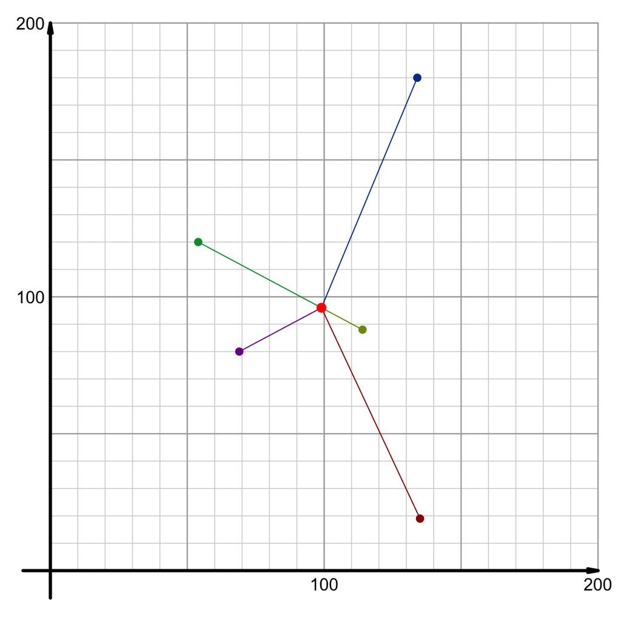

I would recommend setting this up in Desmos using $d=\sqrt{(x_2-99)^2+(y_2-96)^2}$ and using sliders for $x_2$ and $y_2$.

| Player | Position | Distance to beacon (ft) |
| --- | --- | --- |
| 1 | (135,19) |  |
| 2 | (114,88) |  |
| 3 | (54,120) |  |
| 4 | (134,180) |  |
| 5 | (69,80) |  |

I would recommend setting this up in Desmos using $d=\sqrt{(x_2-99)^2+(y_2-96)^2}$ and using sliders for $x_2$ and $y_2$.

$$\sqrt{(135-99)^2+(19-96)^2}~=~85$$

$$\sqrt{(114-99)^2+(88-96)^2}~=~17$$

$$\sqrt{(54-99)^2+(120-96)^2}~=~51$$

$$\sqrt{(134-99)^2+(180-96)^2}~=~91$$

$$\sqrt{(69-99)^2+(80-96)^2}~=~34$$

The [2D distance formula](https://en.wikipedia.org/wiki/Euclidean_distance#Two_dimensions) is an equivalent equation to the [Pythagorean equation](https://en.wikipedia.org/wiki/Pythagorean_theorem). When finding distance between two points on an $xy$-plane, it can be helpful to imagine a [right triangle](https://en.wikipedia.org/wiki/Right_triangle) with its legs horizontal and vertical, and its hypotenuse connecting the points. The length of the hypotenuse is the square root of the sum of the squares of the legs' lengths. Each leg's length is found by taking an absolute difference corresponding coordinates; for example $|x_2-x_1|$ is the length of the horizontal leg, and $|y_2-y_1|$ is the length of the vertical leg.

A square field is 200 feet by 200 feet. The field is marked with a grid pattern, so the Southwest corner is at point $(0,0)$ and the Northeast corner is at point $(200,200)$. Near the middle, at position $(106, 102)$ is a beacon, marked as a large bright-red dot. On the field are 5 players; their positions are listed in the table below. Find how far each player is from the beacon.

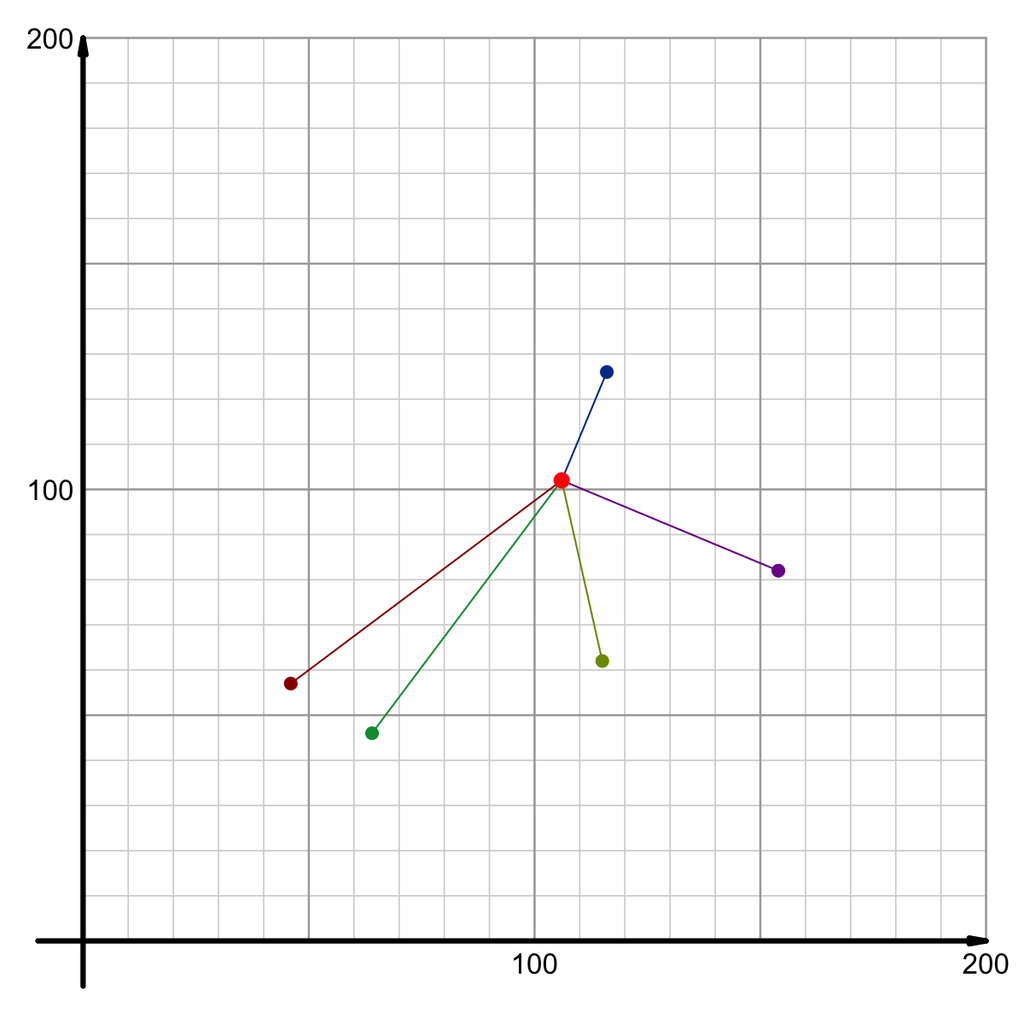

I would recommend setting this up in Desmos using $d=\sqrt{(x_2-106)^2+(y_2-102)^2}$ and using sliders for $x_2$ and $y_2$.

| Player | Position | Distance to beacon (ft) |
| --- | --- | --- |
| 1 | (46,57) |  |
| 2 | (115,62) |  |
| 3 | (64,46) |  |
| 4 | (116,126) |  |
| 5 | (154,82) |  |

I would recommend setting this up in Desmos using $d=\sqrt{(x_2-106)^2+(y_2-102)^2}$ and using sliders for $x_2$ and $y_2$.

$$\sqrt{(46-106)^2+(57-102)^2}~=~75$$

$$\sqrt{(115-106)^2+(62-102)^2}~=~41$$

$$\sqrt{(64-106)^2+(46-102)^2}~=~70$$

$$\sqrt{(116-106)^2+(126-102)^2}~=~26$$

$$\sqrt{(154-106)^2+(82-102)^2}~=~52$$

The [2D distance formula](https://en.wikipedia.org/wiki/Euclidean_distance#Two_dimensions) is an equivalent equation to the [Pythagorean equation](https://en.wikipedia.org/wiki/Pythagorean_theorem). When finding distance between two points on an $xy$-plane, it can be helpful to imagine a [right triangle](https://en.wikipedia.org/wiki/Right_triangle) with its legs horizontal and vertical, and its hypotenuse connecting the points. The length of the hypotenuse is the square root of the sum of the squares of the legs' lengths. Each leg's length is found by taking an absolute difference corresponding coordinates; for example $|x_2-x_1|$ is the length of the horizontal leg, and $|y_2-y_1|$ is the length of the vertical leg.

A square field is 200 feet by 200 feet. The field is marked with a grid pattern, so the Southwest corner is at point $(0,0)$ and the Northeast corner is at point $(200,200)$. Near the middle, at position $(109, 91)$ is a beacon, marked as a large bright-red dot. On the field are 5 players; their positions are listed in the table below. Find how far each player is from the beacon.

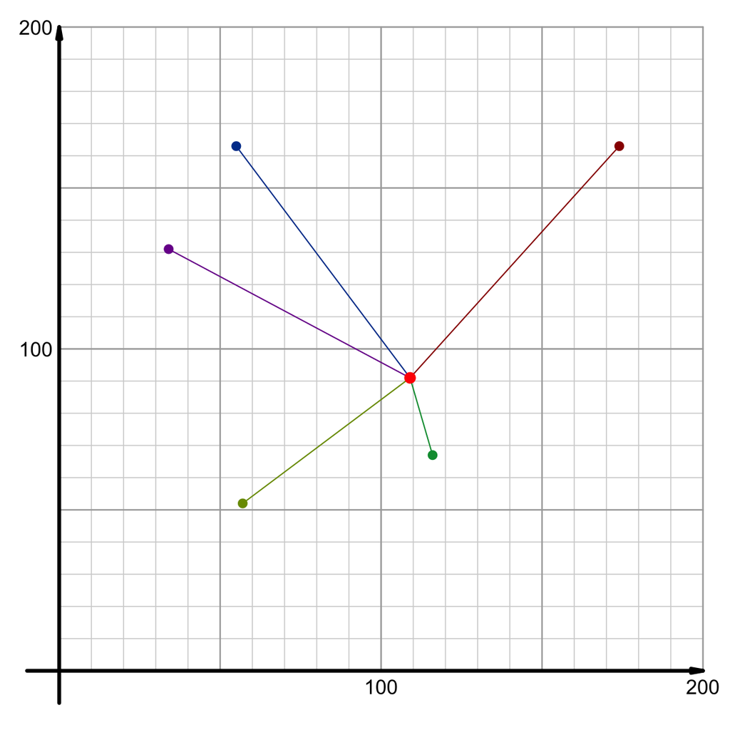

I would recommend setting this up in Desmos using $d=\sqrt{(x_2-109)^2+(y_2-91)^2}$ and using sliders for $x_2$ and $y_2$.

| Player | Position | Distance to beacon (ft) |
| --- | --- | --- |
| 1 | (174,163) |  |
| 2 | (57,52) |  |
| 3 | (116,67) |  |
| 4 | (55,163) |  |
| 5 | (34,131) |  |

I would recommend setting this up in Desmos using $d=\sqrt{(x_2-109)^2+(y_2-91)^2}$ and using sliders for $x_2$ and $y_2$.

$$\sqrt{(174-109)^2+(163-91)^2}~=~97$$

$$\sqrt{(57-109)^2+(52-91)^2}~=~65$$

$$\sqrt{(116-109)^2+(67-91)^2}~=~25$$

$$\sqrt{(55-109)^2+(163-91)^2}~=~90$$

$$\sqrt{(34-109)^2+(131-91)^2}~=~85$$

The [2D distance formula](https://en.wikipedia.org/wiki/Euclidean_distance#Two_dimensions) is an equivalent equation to the [Pythagorean equation](https://en.wikipedia.org/wiki/Pythagorean_theorem). When finding distance between two points on an $xy$-plane, it can be helpful to imagine a [right triangle](https://en.wikipedia.org/wiki/Right_triangle) with its legs horizontal and vertical, and its hypotenuse connecting the points. The length of the hypotenuse is the square root of the sum of the squares of the legs' lengths. Each leg's length is found by taking an absolute difference corresponding coordinates; for example $|x_2-x_1|$ is the length of the horizontal leg, and $|y_2-y_1|$ is the length of the vertical leg.

A square field is 200 feet by 200 feet. The field is marked with a grid pattern, so the Southwest corner is at point $(0,0)$ and the Northeast corner is at point $(200,200)$. Near the middle, at position $(102, 98)$ is a beacon, marked as a large bright-red dot. On the field are 5 players; their positions are listed in the table below. Find how far each player is from the beacon.

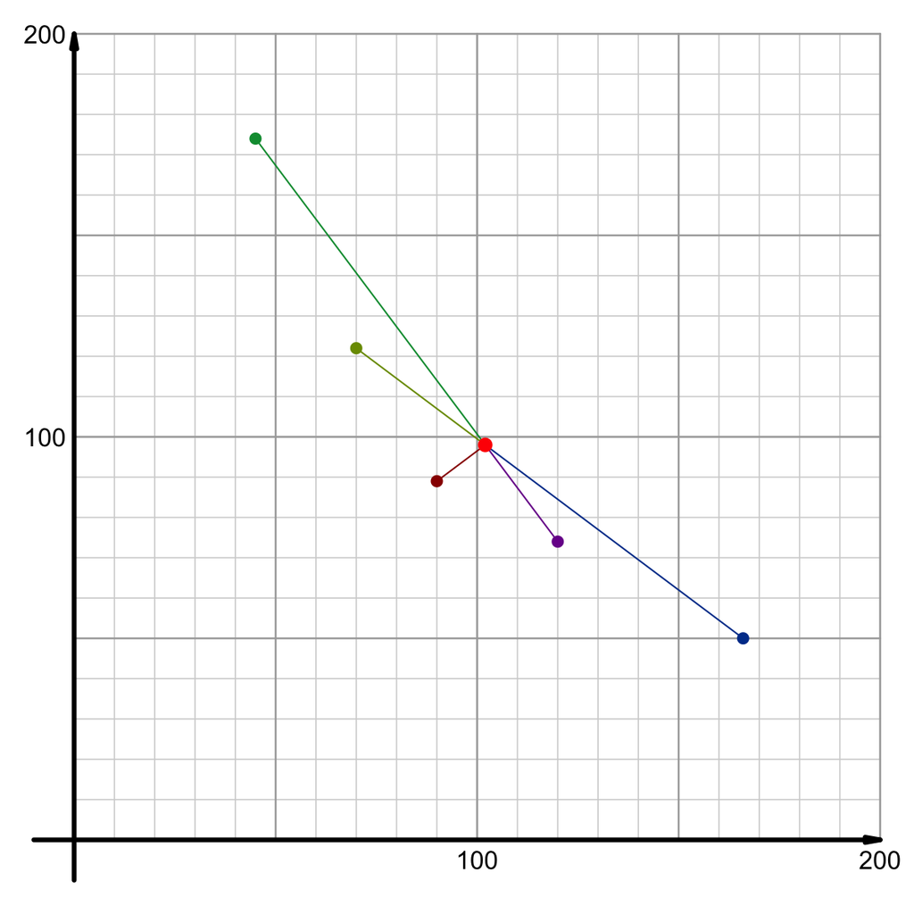

I would recommend setting this up in Desmos using $d=\sqrt{(x_2-102)^2+(y_2-98)^2}$ and using sliders for $x_2$ and $y_2$.

| Player | Position | Distance to beacon (ft) |
| --- | --- | --- |
| 1 | (90,89) |  |
| 2 | (70,122) |  |
| 3 | (45,174) |  |
| 4 | (166,50) |  |
| 5 | (120,74) |  |

I would recommend setting this up in Desmos using $d=\sqrt{(x_2-102)^2+(y_2-98)^2}$ and using sliders for $x_2$ and $y_2$.

$$\sqrt{(90-102)^2+(89-98)^2}~=~15$$

$$\sqrt{(70-102)^2+(122-98)^2}~=~40$$

$$\sqrt{(45-102)^2+(174-98)^2}~=~95$$

$$\sqrt{(166-102)^2+(50-98)^2}~=~80$$

$$\sqrt{(120-102)^2+(74-98)^2}~=~30$$

The [2D distance formula](https://en.wikipedia.org/wiki/Euclidean_distance#Two_dimensions) is an equivalent equation to the [Pythagorean equation](https://en.wikipedia.org/wiki/Pythagorean_theorem). When finding distance between two points on an $xy$-plane, it can be helpful to imagine a [right triangle](https://en.wikipedia.org/wiki/Right_triangle) with its legs horizontal and vertical, and its hypotenuse connecting the points. The length of the hypotenuse is the square root of the sum of the squares of the legs' lengths. Each leg's length is found by taking an absolute difference corresponding coordinates; for example $|x_2-x_1|$ is the length of the horizontal leg, and $|y_2-y_1|$ is the length of the vertical leg.

A square field is 200 feet by 200 feet. The field is marked with a grid pattern, so the Southwest corner is at point $(0,0)$ and the Northeast corner is at point $(200,200)$. Near the middle, at position $(108, 104)$ is a beacon, marked as a large bright-red dot. On the field are 5 players; their positions are listed in the table below. Find how far each player is from the beacon.

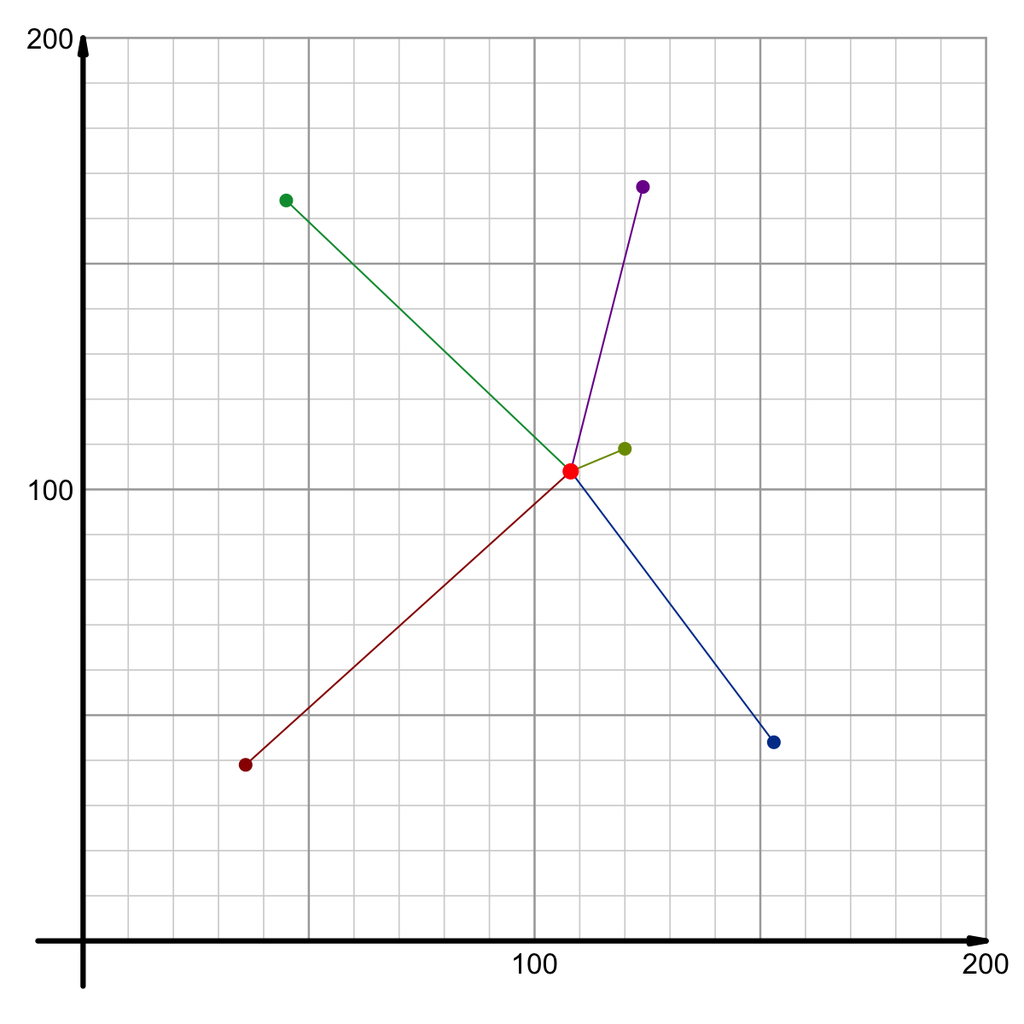

I would recommend setting this up in Desmos using $d=\sqrt{(x_2-108)^2+(y_2-104)^2}$ and using sliders for $x_2$ and $y_2$.

| Player | Position | Distance to beacon (ft) |
| --- | --- | --- |
| 1 | (36,39) |  |
| 2 | (120,109) |  |
| 3 | (45,164) |  |
| 4 | (153,44) |  |
| 5 | (124,167) |  |

I would recommend setting this up in Desmos using $d=\sqrt{(x_2-108)^2+(y_2-104)^2}$ and using sliders for $x_2$ and $y_2$.

$$\sqrt{(36-108)^2+(39-104)^2}~=~97$$

$$\sqrt{(120-108)^2+(109-104)^2}~=~13$$

$$\sqrt{(45-108)^2+(164-104)^2}~=~87$$

$$\sqrt{(153-108)^2+(44-104)^2}~=~75$$

$$\sqrt{(124-108)^2+(167-104)^2}~=~65$$

The [2D distance formula](https://en.wikipedia.org/wiki/Euclidean_distance#Two_dimensions) is an equivalent equation to the [Pythagorean equation](https://en.wikipedia.org/wiki/Pythagorean_theorem). When finding distance between two points on an $xy$-plane, it can be helpful to imagine a [right triangle](https://en.wikipedia.org/wiki/Right_triangle) with its legs horizontal and vertical, and its hypotenuse connecting the points. The length of the hypotenuse is the square root of the sum of the squares of the legs' lengths. Each leg's length is found by taking an absolute difference corresponding coordinates; for example $|x_2-x_1|$ is the length of the horizontal leg, and $|y_2-y_1|$ is the length of the vertical leg.

A square field is 200 feet by 200 feet. The field is marked with a grid pattern, so the Southwest corner is at point $(0,0)$ and the Northeast corner is at point $(200,200)$. Near the middle, at position $(92, 101)$ is a beacon, marked as a large bright-red dot. On the field are 5 players; their positions are listed in the table below. Find how far each player is from the beacon.

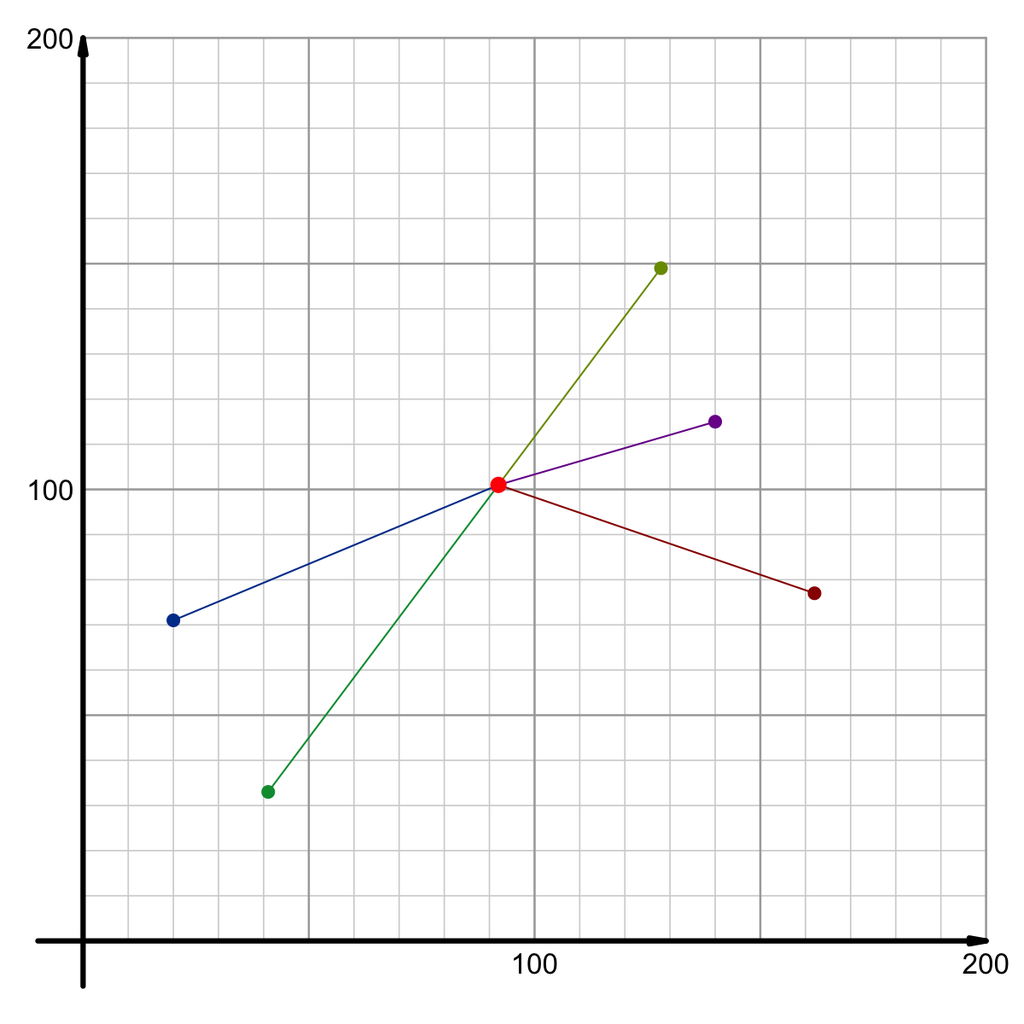

I would recommend setting this up in Desmos using $d=\sqrt{(x_2-92)^2+(y_2-101)^2}$ and using sliders for $x_2$ and $y_2$.

| Player | Position | Distance to beacon (ft) |
| --- | --- | --- |
| 1 | (162,77) |  |
| 2 | (128,149) |  |
| 3 | (41,33) |  |
| 4 | (20,71) |  |
| 5 | (140,115) |  |

I would recommend setting this up in Desmos using $d=\sqrt{(x_2-92)^2+(y_2-101)^2}$ and using sliders for $x_2$ and $y_2$.

$$\sqrt{(162-92)^2+(77-101)^2}~=~74$$

$$\sqrt{(128-92)^2+(149-101)^2}~=~60$$

$$\sqrt{(41-92)^2+(33-101)^2}~=~85$$

$$\sqrt{(20-92)^2+(71-101)^2}~=~78$$

$$\sqrt{(140-92)^2+(115-101)^2}~=~50$$

The [2D distance formula](https://en.wikipedia.org/wiki/Euclidean_distance#Two_dimensions) is an equivalent equation to the [Pythagorean equation](https://en.wikipedia.org/wiki/Pythagorean_theorem). When finding distance between two points on an $xy$-plane, it can be helpful to imagine a [right triangle](https://en.wikipedia.org/wiki/Right_triangle) with its legs horizontal and vertical, and its hypotenuse connecting the points. The length of the hypotenuse is the square root of the sum of the squares of the legs' lengths. Each leg's length is found by taking an absolute difference corresponding coordinates; for example $|x_2-x_1|$ is the length of the horizontal leg, and $|y_2-y_1|$ is the length of the vertical leg.

A square field is 200 feet by 200 feet. The field is marked with a grid pattern, so the Southwest corner is at point $(0,0)$ and the Northeast corner is at point $(200,200)$. Near the middle, at position $(109, 97)$ is a beacon, marked as a large bright-red dot. On the field are 5 players; their positions are listed in the table below. Find how far each player is from the beacon.

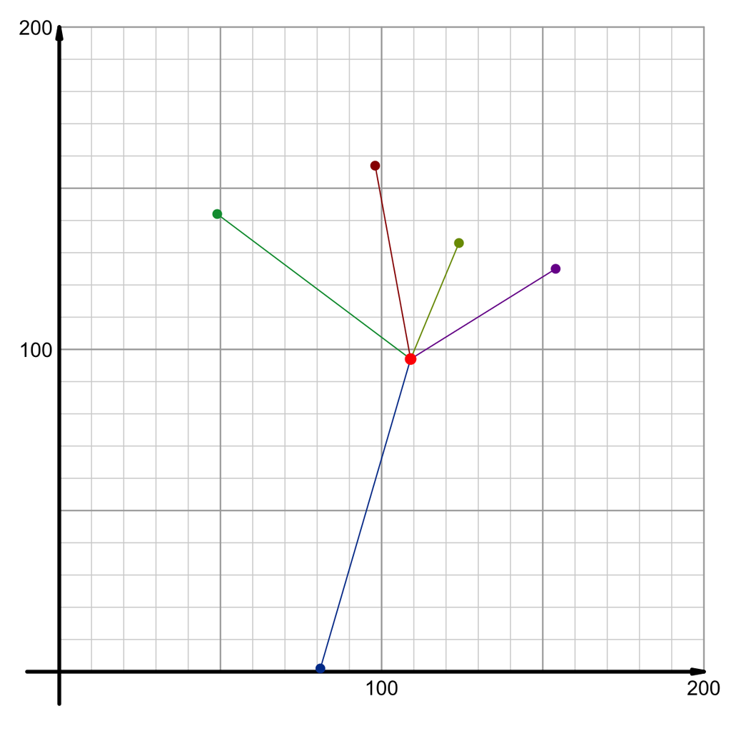

I would recommend setting this up in Desmos using $d=\sqrt{(x_2-109)^2+(y_2-97)^2}$ and using sliders for $x_2$ and $y_2$.

| Player | Position | Distance to beacon (ft) |
| --- | --- | --- |
| 1 | (98,157) |  |
| 2 | (124,133) |  |
| 3 | (49,142) |  |
| 4 | (81,1) |  |
| 5 | (154,125) |  |

I would recommend setting this up in Desmos using $d=\sqrt{(x_2-109)^2+(y_2-97)^2}$ and using sliders for $x_2$ and $y_2$.

$$\sqrt{(98-109)^2+(157-97)^2}~=~61$$

$$\sqrt{(124-109)^2+(133-97)^2}~=~39$$

$$\sqrt{(49-109)^2+(142-97)^2}~=~75$$

$$\sqrt{(81-109)^2+(1-97)^2}~=~100$$

$$\sqrt{(154-109)^2+(125-97)^2}~=~53$$

The [2D distance formula](https://en.wikipedia.org/wiki/Euclidean_distance#Two_dimensions) is an equivalent equation to the [Pythagorean equation](https://en.wikipedia.org/wiki/Pythagorean_theorem). When finding distance between two points on an $xy$-plane, it can be helpful to imagine a [right triangle](https://en.wikipedia.org/wiki/Right_triangle) with its legs horizontal and vertical, and its hypotenuse connecting the points. The length of the hypotenuse is the square root of the sum of the squares of the legs' lengths. Each leg's length is found by taking an absolute difference corresponding coordinates; for example $|x_2-x_1|$ is the length of the horizontal leg, and $|y_2-y_1|$ is the length of the vertical leg.

A square field is 200 feet by 200 feet. The field is marked with a grid pattern, so the Southwest corner is at point $(0,0)$ and the Northeast corner is at point $(200,200)$. Near the middle, at position $(96, 99)$ is a beacon, marked as a large bright-red dot. On the field are 5 players; their positions are listed in the table below. Find how far each player is from the beacon.

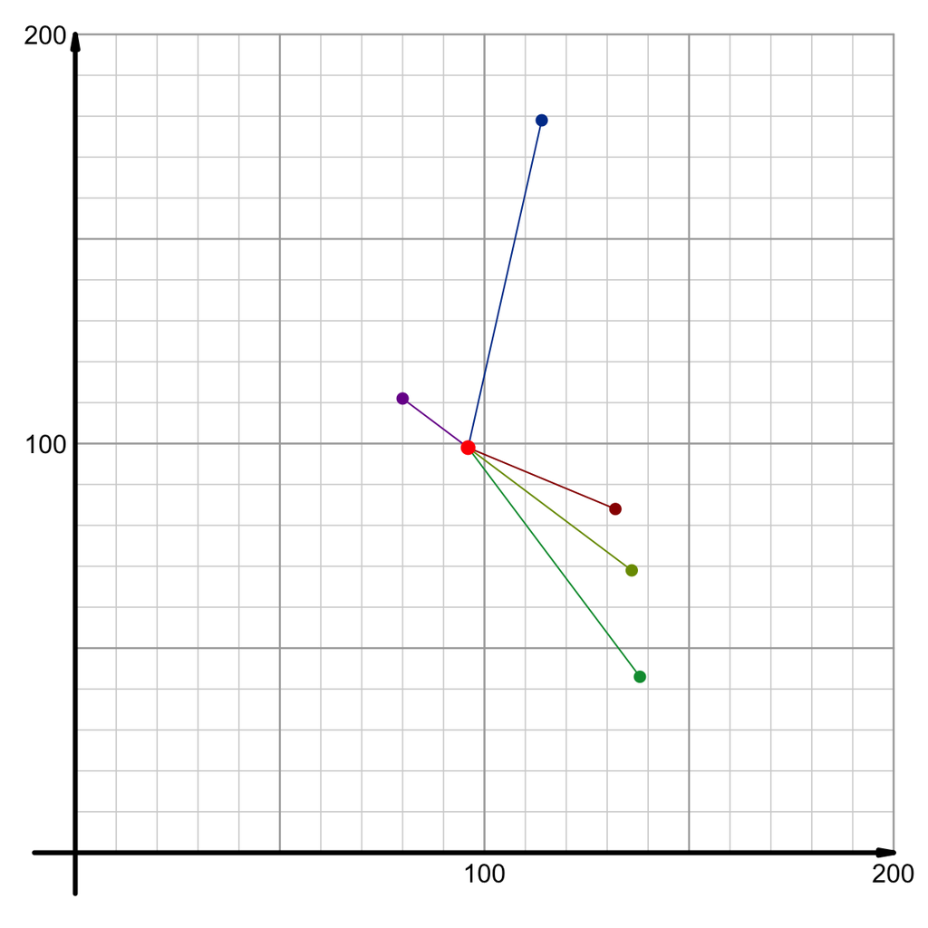

I would recommend setting this up in Desmos using $d=\sqrt{(x_2-96)^2+(y_2-99)^2}$ and using sliders for $x_2$ and $y_2$.

| Player | Position | Distance to beacon (ft) |
| --- | --- | --- |
| 1 | (132,84) |  |
| 2 | (136,69) |  |
| 3 | (138,43) |  |
| 4 | (114,179) |  |
| 5 | (80,111) |  |

I would recommend setting this up in Desmos using $d=\sqrt{(x_2-96)^2+(y_2-99)^2}$ and using sliders for $x_2$ and $y_2$.

$$\sqrt{(132-96)^2+(84-99)^2}~=~39$$

$$\sqrt{(136-96)^2+(69-99)^2}~=~50$$

$$\sqrt{(138-96)^2+(43-99)^2}~=~70$$

$$\sqrt{(114-96)^2+(179-99)^2}~=~82$$

$$\sqrt{(80-96)^2+(111-99)^2}~=~20$$

The [2D distance formula](https://en.wikipedia.org/wiki/Euclidean_distance#Two_dimensions) is an equivalent equation to the [Pythagorean equation](https://en.wikipedia.org/wiki/Pythagorean_theorem). When finding distance between two points on an $xy$-plane, it can be helpful to imagine a [right triangle](https://en.wikipedia.org/wiki/Right_triangle) with its legs horizontal and vertical, and its hypotenuse connecting the points. The length of the hypotenuse is the square root of the sum of the squares of the legs' lengths. Each leg's length is found by taking an absolute difference corresponding coordinates; for example $|x_2-x_1|$ is the length of the horizontal leg, and $|y_2-y_1|$ is the length of the vertical leg.

A square field is 200 feet by 200 feet. The field is marked with a grid pattern, so the Southwest corner is at point $(0,0)$ and the Northeast corner is at point $(200,200)$. Near the middle, at position $(100, 97)$ is a beacon, marked as a large bright-red dot. On the field are 5 players; their positions are listed in the table below. Find how far each player is from the beacon.

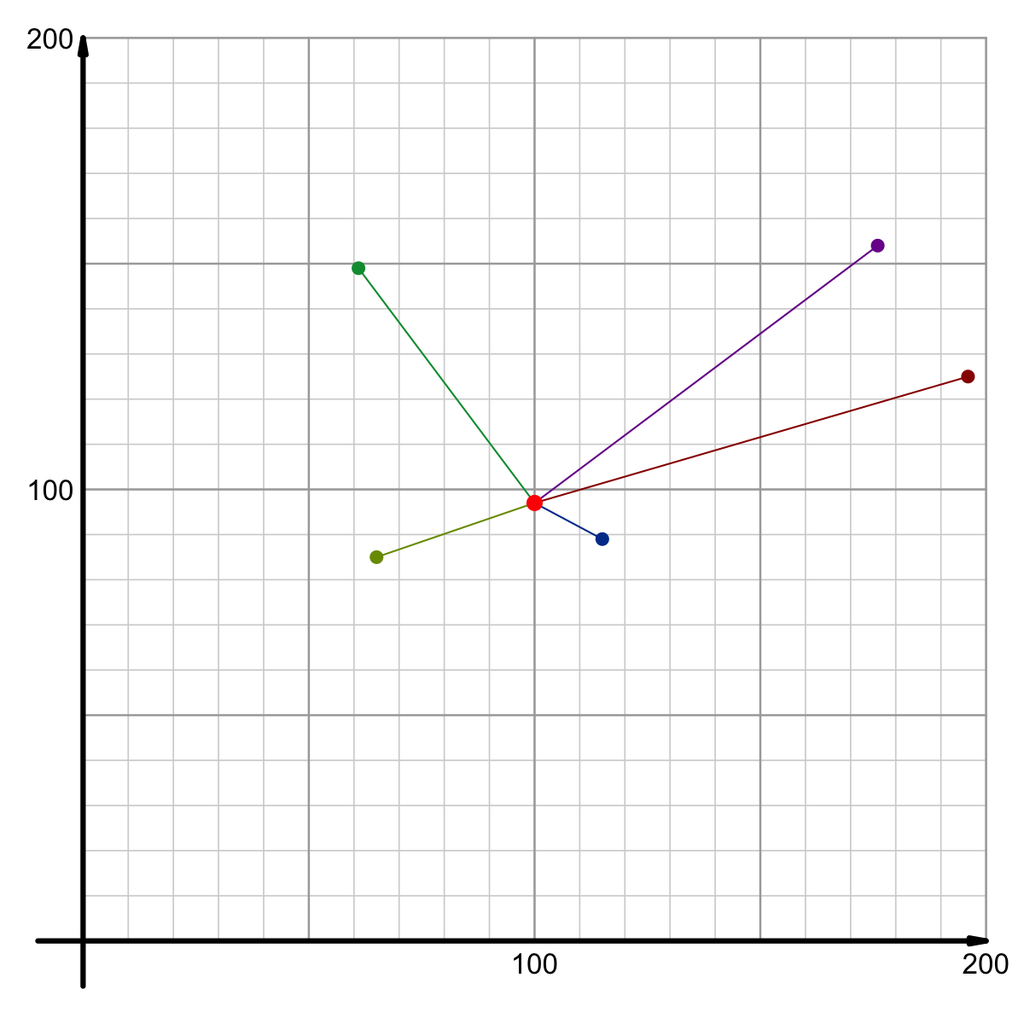

I would recommend setting this up in Desmos using $d=\sqrt{(x_2-100)^2+(y_2-97)^2}$ and using sliders for $x_2$ and $y_2$.

| Player | Position | Distance to beacon (ft) |
| --- | --- | --- |
| 1 | (196,125) |  |
| 2 | (65,85) |  |
| 3 | (61,149) |  |
| 4 | (115,89) |  |
| 5 | (176,154) |  |

I would recommend setting this up in Desmos using $d=\sqrt{(x_2-100)^2+(y_2-97)^2}$ and using sliders for $x_2$ and $y_2$.

$$\sqrt{(196-100)^2+(125-97)^2}~=~100$$

$$\sqrt{(65-100)^2+(85-97)^2}~=~37$$

$$\sqrt{(61-100)^2+(149-97)^2}~=~65$$

$$\sqrt{(115-100)^2+(89-97)^2}~=~17$$

$$\sqrt{(176-100)^2+(154-97)^2}~=~95$$

Using [Desmos](https://www.desmos.com/calculator), determine which of the given points are within a distance of 13 units from point (6, -5).

1. Graph the inequality $(x-6)^2+(y+5)^2~\le~13^2$ as the first item in Desmos.
2. Enter each point as a [Cartesian coordinate pair](https://en.wikipedia.org/wiki/Abscissa_and_ordinate). Actually, you should be able to copy/paste all the points as a single item (using commas to separate the points):
   - (18,-1), (14,5), (4,8), (3,9), (-2,4), (-5,4), (-6,-9), (1,-17), (11,-16), (17,-11)
3. Click "Label" to label the points.
4. Determine which points are in the shaded area. If a point is exactly on the boundary, count that point as within the distance. You might need to zoom in on points to be sure.

(18,-1)(14,5)(4,8)(3,9)(-2,4)(-5,4)(-6,-9)(1,-17)(11,-16)(17,-11)

Follow the directions given in the prompt. I've plotted the inequality and the points below, using two different marks to indicate whether the point in inside the boundary or outside the boundary. Notice the points should be listed (mostly) in a counter-clockwise order, starting from 3 o'clock (see [standard position of an angle](https://libraryguides.centennialcollege.ca/c.php?g=716824&p=5112868)).

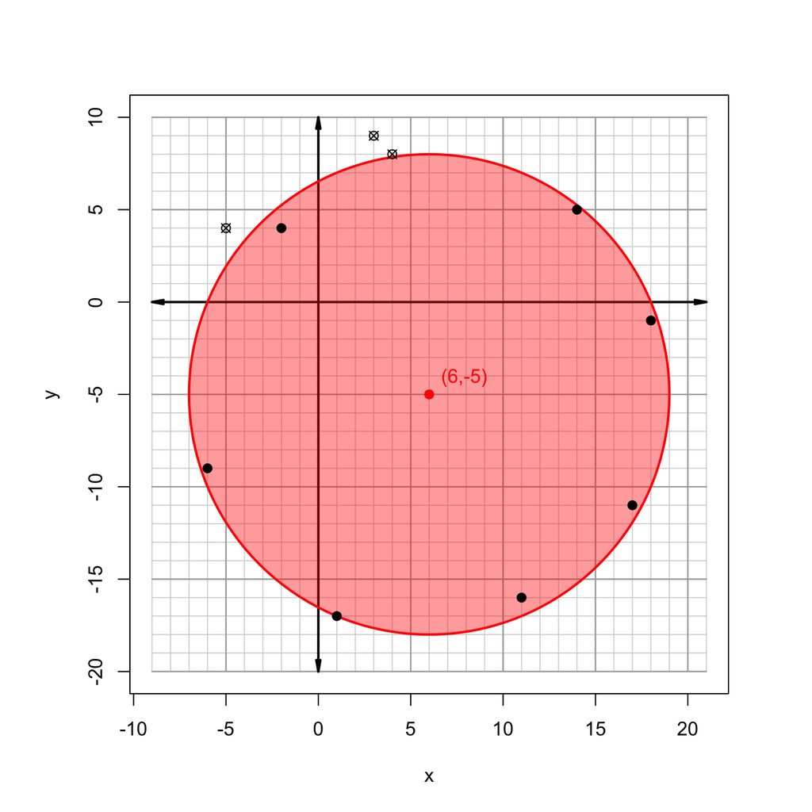

- point (18,-1) is in
- point (14,5) is in
- point (4,8) is NOT in
- point (3,9) is NOT in
- point (-2,4) is in
- point (-5,4) is NOT in
- point (-6,-9) is in
- point (1,-17) is in
- point (11,-16) is in
- point (17,-11) is in

Using [Desmos](https://www.desmos.com/calculator), determine which of the given points are within a distance of 15 units from point (-6, 5).

1. Graph the inequality $(x+6)^2+(y-5)^2~\le~15^2$ as the first item in Desmos.
2. Enter each point as a [Cartesian coordinate pair](https://en.wikipedia.org/wiki/Abscissa_and_ordinate). Actually, you should be able to copy/paste all the points as a single item (using commas to separate the points):
   - (9,9), (8,11), (0,18), (-10,19), (-21,10), (-20,3), (-19,-3), (-8,-10), (-2,-8), (9,2)
3. Click "Label" to label the points.
4. Determine which points are in the shaded area. If a point is exactly on the boundary, count that point as within the distance. You might need to zoom in on points to be sure.

(9,9)(8,11)(0,18)(-10,19)(-21,10)(-20,3)(-19,-3)(-8,-10)(-2,-8)(9,2)

Follow the directions given in the prompt. I've plotted the inequality and the points below, using two different marks to indicate whether the point in inside the boundary or outside the boundary. Notice the points should be listed (mostly) in a counter-clockwise order, starting from 3 o'clock (see [standard position of an angle](https://libraryguides.centennialcollege.ca/c.php?g=716824&p=5112868)).

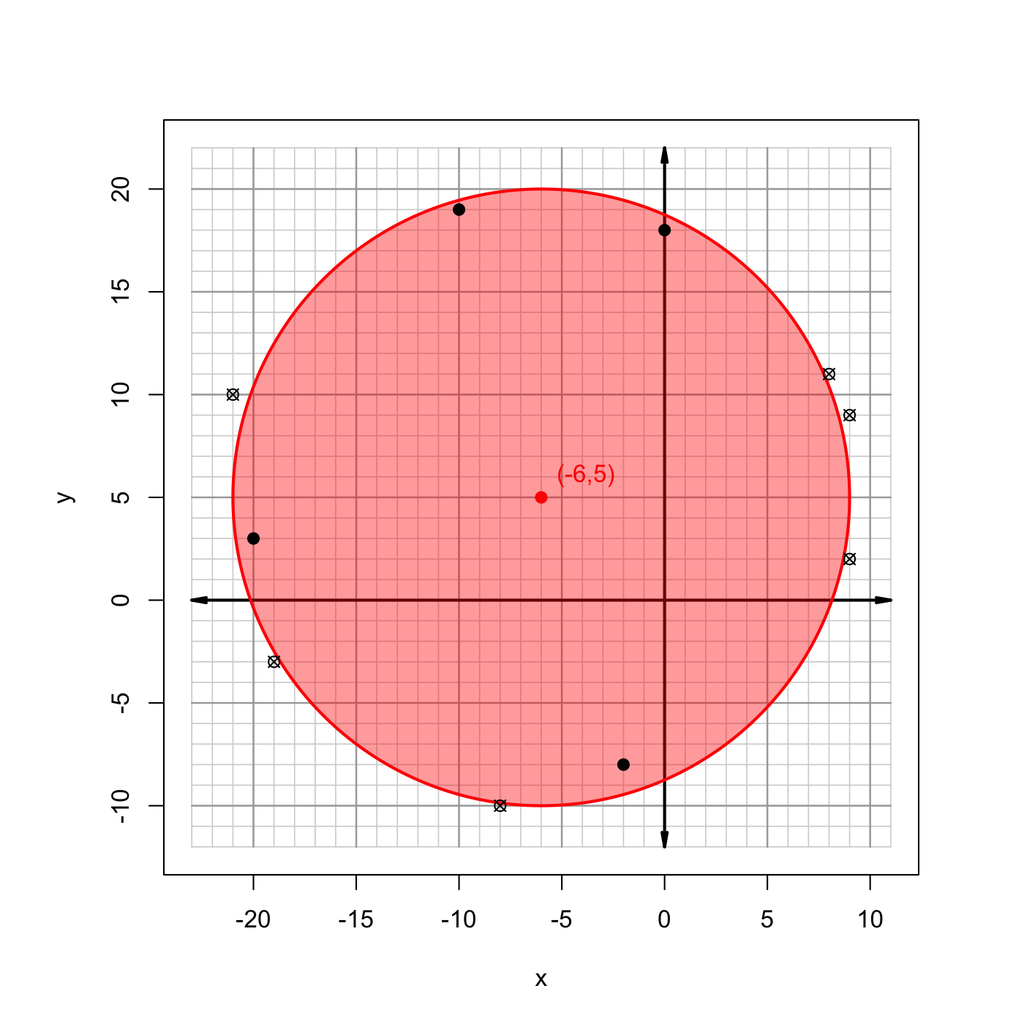

- point (9,9) is NOT in
- point (8,11) is NOT in
- point (0,18) is in
- point (-10,19) is in
- point (-21,10) is NOT in
- point (-20,3) is in
- point (-19,-3) is NOT in
- point (-8,-10) is NOT in
- point (-2,-8) is in
- point (9,2) is NOT in

Using [Desmos](https://www.desmos.com/calculator), determine which of the given points are within a distance of 10 units from point (-3, 7).

1. Graph the inequality $(x+3)^2+(y-7)^2~\le~10^2$ as the first item in Desmos.
2. Enter each point as a [Cartesian coordinate pair](https://en.wikipedia.org/wiki/Abscissa_and_ordinate). Actually, you should be able to copy/paste all the points as a single item (using commas to separate the points):
   - (3,14), (-1,17), (-3,18), (-7,16), (-13,12), (-13,3), (-6,-3), (-5,-3), (2,-1), (8,5)
3. Click "Label" to label the points.
4. Determine which points are in the shaded area. If a point is exactly on the boundary, count that point as within the distance. You might need to zoom in on points to be sure.

(3,14)(-1,17)(-3,18)(-7,16)(-13,12)(-13,3)(-6,-3)(-5,-3)(2,-1)(8,5)

Follow the directions given in the prompt. I've plotted the inequality and the points below, using two different marks to indicate whether the point in inside the boundary or outside the boundary. Notice the points should be listed (mostly) in a counter-clockwise order, starting from 3 o'clock (see [standard position of an angle](https://libraryguides.centennialcollege.ca/c.php?g=716824&p=5112868)).

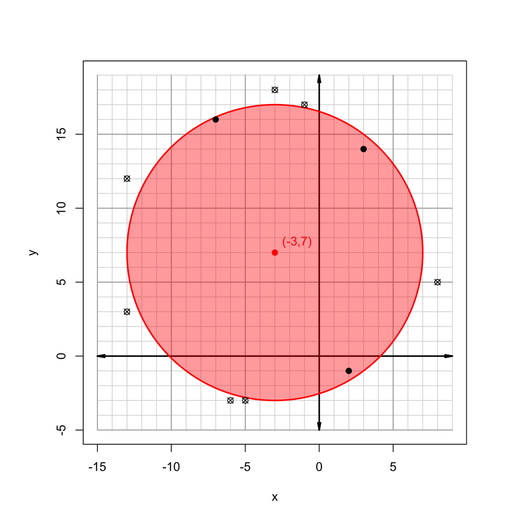

- point (3,14) is in
- point (-1,17) is NOT in
- point (-3,18) is NOT in
- point (-7,16) is in
- point (-13,12) is NOT in
- point (-13,3) is NOT in
- point (-6,-3) is NOT in
- point (-5,-3) is NOT in
- point (2,-1) is in
- point (8,5) is NOT in

Using [Desmos](https://www.desmos.com/calculator), determine which of the given points are within a distance of 14 units from point (7, 5).

1. Graph the inequality $(x-7)^2+(y-5)^2~\le~14^2$ as the first item in Desmos.
2. Enter each point as a [Cartesian coordinate pair](https://en.wikipedia.org/wiki/Abscissa_and_ordinate). Actually, you should be able to copy/paste all the points as a single item (using commas to separate the points):
   - (19,12), (17,13), (5,18), (-3,15), (-8,8), (-7,1), (-5,0), (3,-9), (15,-6), (22,2)
3. Click "Label" to label the points.
4. Determine which points are in the shaded area. If a point is exactly on the boundary, count that point as within the distance. You might need to zoom in on points to be sure.

(19,12)(17,13)(5,18)(-3,15)(-8,8)(-7,1)(-5,0)(3,-9)(15,-6)(22,2)

Follow the directions given in the prompt. I've plotted the inequality and the points below, using two different marks to indicate whether the point in inside the boundary or outside the boundary. Notice the points should be listed (mostly) in a counter-clockwise order, starting from 3 o'clock (see [standard position of an angle](https://libraryguides.centennialcollege.ca/c.php?g=716824&p=5112868)).

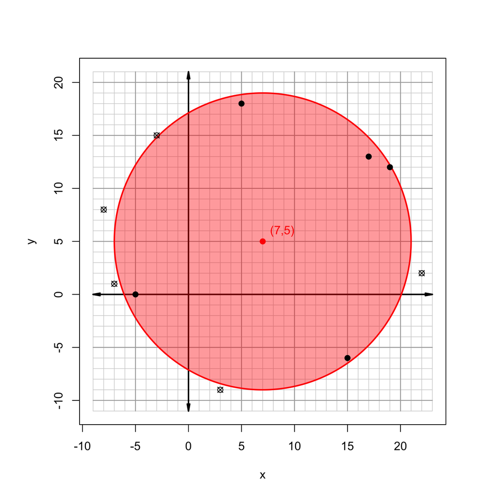

- point (19,12) is in
- point (17,13) is in
- point (5,18) is in
- point (-3,15) is NOT in
- point (-8,8) is NOT in
- point (-7,1) is NOT in
- point (-5,0) is in
- point (3,-9) is NOT in
- point (15,-6) is in
- point (22,2) is NOT in

Using [Desmos](https://www.desmos.com/calculator), determine which of the given points are within a distance of 11 units from point (-7, -6).

1. Graph the inequality $(x+7)^2+(y+6)^2~\le~11^2$ as the first item in Desmos.
2. Enter each point as a [Cartesian coordinate pair](https://en.wikipedia.org/wiki/Abscissa_and_ordinate). Actually, you should be able to copy/paste all the points as a single item (using commas to separate the points):
   - (4,-3), (-1,2), (-5,5), (-6,5), (-14,4), (-18,-3), (-19,-7), (-13,-14), (-4,-16), (3,-12)
3. Click "Label" to label the points.
4. Determine which points are in the shaded area. If a point is exactly on the boundary, count that point as within the distance. You might need to zoom in on points to be sure.

(4,-3)(-1,2)(-5,5)(-6,5)(-14,4)(-18,-3)(-19,-7)(-13,-14)(-4,-16)(3,-12)

Follow the directions given in the prompt. I've plotted the inequality and the points below, using two different marks to indicate whether the point in inside the boundary or outside the boundary. Notice the points should be listed (mostly) in a counter-clockwise order, starting from 3 o'clock (see [standard position of an angle](https://libraryguides.centennialcollege.ca/c.php?g=716824&p=5112868)).

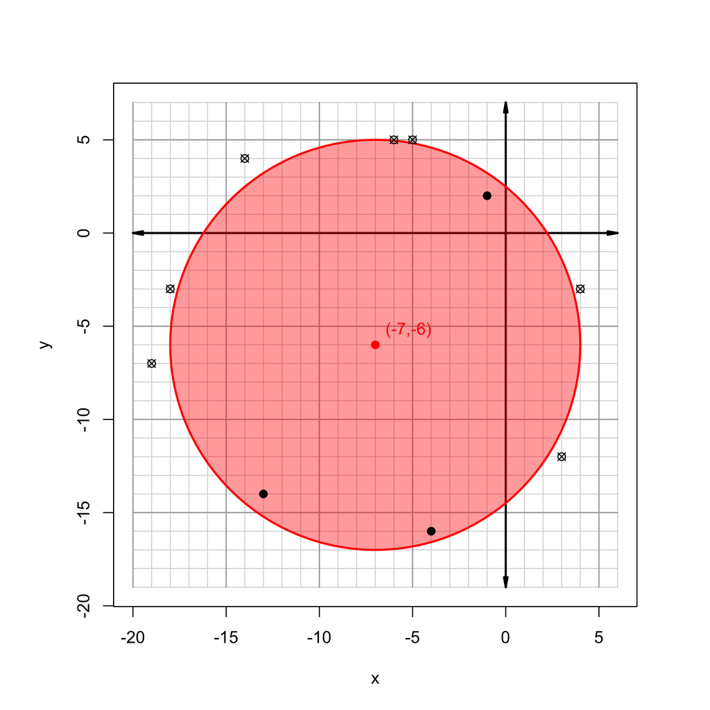

- point (4,-3) is NOT in
- point (-1,2) is in
- point (-5,5) is NOT in
- point (-6,5) is NOT in
- point (-14,4) is NOT in
- point (-18,-3) is NOT in
- point (-19,-7) is NOT in
- point (-13,-14) is in
- point (-4,-16) is in
- point (3,-12) is NOT in

Using [Desmos](https://www.desmos.com/calculator), determine which of the given points are within a distance of 15 units from point (4, -2).

1. Graph the inequality $(x-4)^2+(y+2)^2~\le~15^2$ as the first item in Desmos.
2. Enter each point as a [Cartesian coordinate pair](https://en.wikipedia.org/wiki/Abscissa_and_ordinate). Actually, you should be able to copy/paste all the points as a single item (using commas to separate the points):
   - (20,0), (13,9), (8,12), (-4,11), (-9,4), (-11,-6), (-11,-9), (-2,-16), (13,-14), (17,-6)
3. Click "Label" to label the points.
4. Determine which points are in the shaded area. If a point is exactly on the boundary, count that point as within the distance. You might need to zoom in on points to be sure.

(20,0)(13,9)(8,12)(-4,11)(-9,4)(-11,-6)(-11,-9)(-2,-16)(13,-14)(17,-6)

Follow the directions given in the prompt. I've plotted the inequality and the points below, using two different marks to indicate whether the point in inside the boundary or outside the boundary. Notice the points should be listed (mostly) in a counter-clockwise order, starting from 3 o'clock (see [standard position of an angle](https://libraryguides.centennialcollege.ca/c.php?g=716824&p=5112868)).

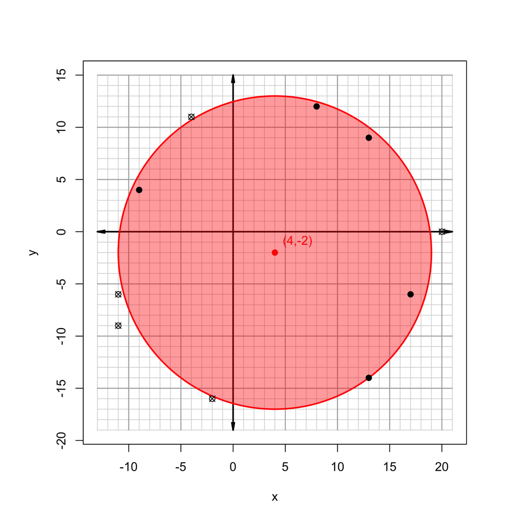

- point (20,0) is NOT in
- point (13,9) is in
- point (8,12) is in
- point (-4,11) is NOT in
- point (-9,4) is in
- point (-11,-6) is NOT in
- point (-11,-9) is NOT in
- point (-2,-16) is NOT in
- point (13,-14) is in
- point (17,-6) is in

Using [Desmos](https://www.desmos.com/calculator), determine which of the given points are within a distance of 13 units from point (4, 3).

1. Graph the inequality $(x-4)^2+(y-3)^2~\le~13^2$ as the first item in Desmos.
2. Enter each point as a [Cartesian coordinate pair](https://en.wikipedia.org/wiki/Abscissa_and_ordinate). Actually, you should be able to copy/paste all the points as a single item (using commas to separate the points):
   - (17,3), (15,10), (10,15), (-1,16), (-5,11), (-9,5), (-8,2), (-5,-7), (5,-10), (17,-2)
3. Click "Label" to label the points.
4. Determine which points are in the shaded area. If a point is exactly on the boundary, count that point as within the distance. You might need to zoom in on points to be sure.

(17,3)(15,10)(10,15)(-1,16)(-5,11)(-9,5)(-8,2)(-5,-7)(5,-10)(17,-2)

Follow the directions given in the prompt. I've plotted the inequality and the points below, using two different marks to indicate whether the point in inside the boundary or outside the boundary. Notice the points should be listed (mostly) in a counter-clockwise order, starting from 3 o'clock (see [standard position of an angle](https://libraryguides.centennialcollege.ca/c.php?g=716824&p=5112868)).

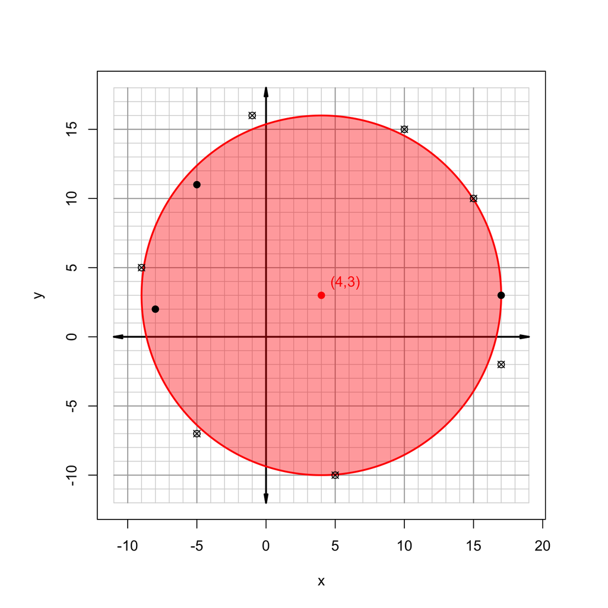

- point (17,3) is in
- point (15,10) is NOT in
- point (10,15) is NOT in
- point (-1,16) is NOT in
- point (-5,11) is in
- point (-9,5) is NOT in
- point (-8,2) is in
- point (-5,-7) is NOT in
- point (5,-10) is NOT in
- point (17,-2) is NOT in

Using [Desmos](https://www.desmos.com/calculator), determine which of the given points are within a distance of 13 units from point (-4, 8).

1. Graph the inequality $(x+4)^2+(y-8)^2~\le~13^2$ as the first item in Desmos.
2. Enter each point as a [Cartesian coordinate pair](https://en.wikipedia.org/wiki/Abscissa_and_ordinate). Actually, you should be able to copy/paste all the points as a single item (using commas to separate the points):
   - (10,10), (4,20), (-4,20), (-7,21), (-14,18), (-17,5), (-8,-4), (-4,-5), (-4,-4), (5,-3)
3. Click "Label" to label the points.
4. Determine which points are in the shaded area. If a point is exactly on the boundary, count that point as within the distance. You might need to zoom in on points to be sure.

(10,10)(4,20)(-4,20)(-7,21)(-14,18)(-17,5)(-8,-4)(-4,-5)(-4,-4)(5,-3)

Follow the directions given in the prompt. I've plotted the inequality and the points below, using two different marks to indicate whether the point in inside the boundary or outside the boundary. Notice the points should be listed (mostly) in a counter-clockwise order, starting from 3 o'clock (see [standard position of an angle](https://libraryguides.centennialcollege.ca/c.php?g=716824&p=5112868)).

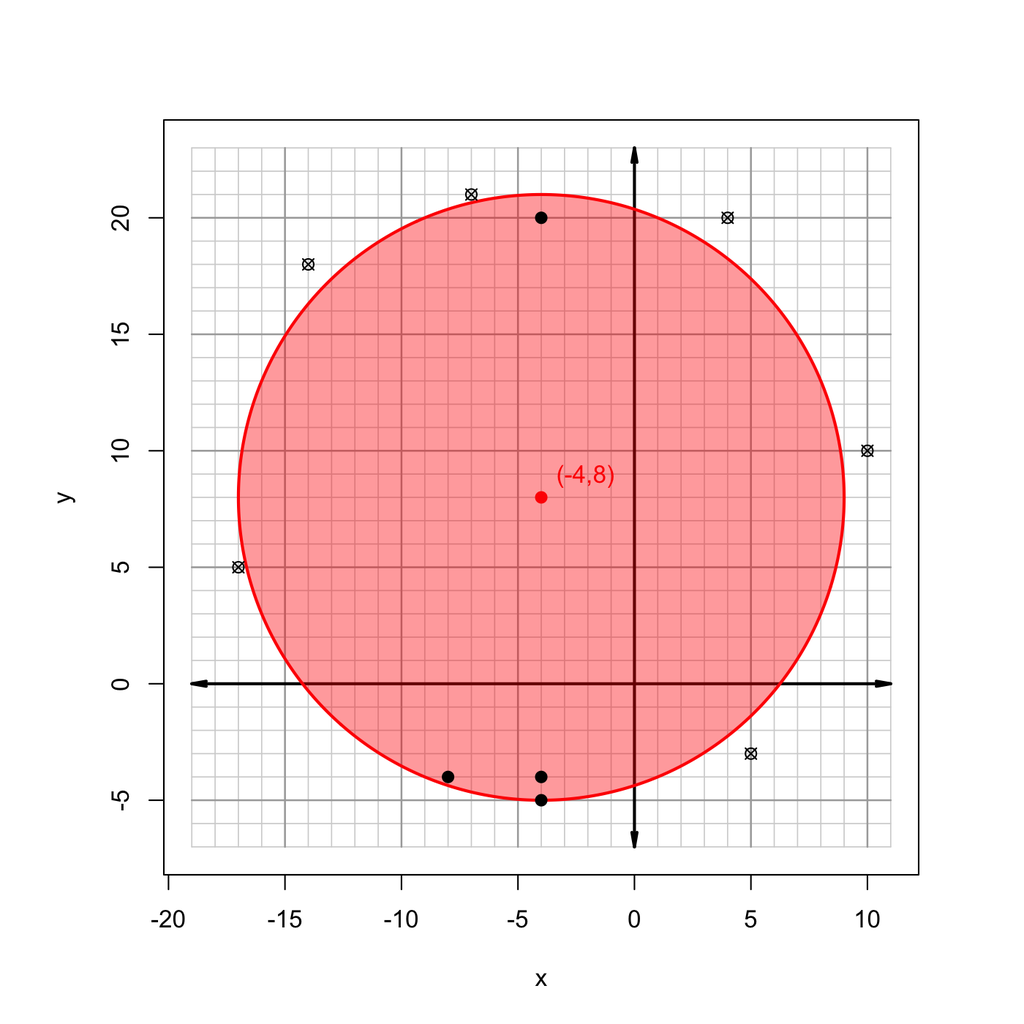

- point (10,10) is NOT in
- point (4,20) is NOT in
- point (-4,20) is in
- point (-7,21) is NOT in
- point (-14,18) is NOT in
- point (-17,5) is NOT in
- point (-8,-4) is in
- point (-4,-5) is in
- point (-4,-4) is in
- point (5,-3) is NOT in

Using [Desmos](https://www.desmos.com/calculator), determine which of the given points are within a distance of 8 units from point (-5, 4).

1. Graph the inequality $(x+5)^2+(y-4)^2~\le~8^2$ as the first item in Desmos.
2. Enter each point as a [Cartesian coordinate pair](https://en.wikipedia.org/wiki/Abscissa_and_ordinate). Actually, you should be able to copy/paste all the points as a single item (using commas to separate the points):
   - (1,8), (-1,12), (-6,11), (-10,8), (-12,4), (-12,3), (-8,-3), (-5,-3), (1,-3), (3,2)
3. Click "Label" to label the points.
4. Determine which points are in the shaded area. If a point is exactly on the boundary, count that point as within the distance. You might need to zoom in on points to be sure.

(1,8)(-1,12)(-6,11)(-10,8)(-12,4)(-12,3)(-8,-3)(-5,-3)(1,-3)(3,2)

Follow the directions given in the prompt. I've plotted the inequality and the points below, using two different marks to indicate whether the point in inside the boundary or outside the boundary. Notice the points should be listed (mostly) in a counter-clockwise order, starting from 3 o'clock (see [standard position of an angle](https://libraryguides.centennialcollege.ca/c.php?g=716824&p=5112868)).

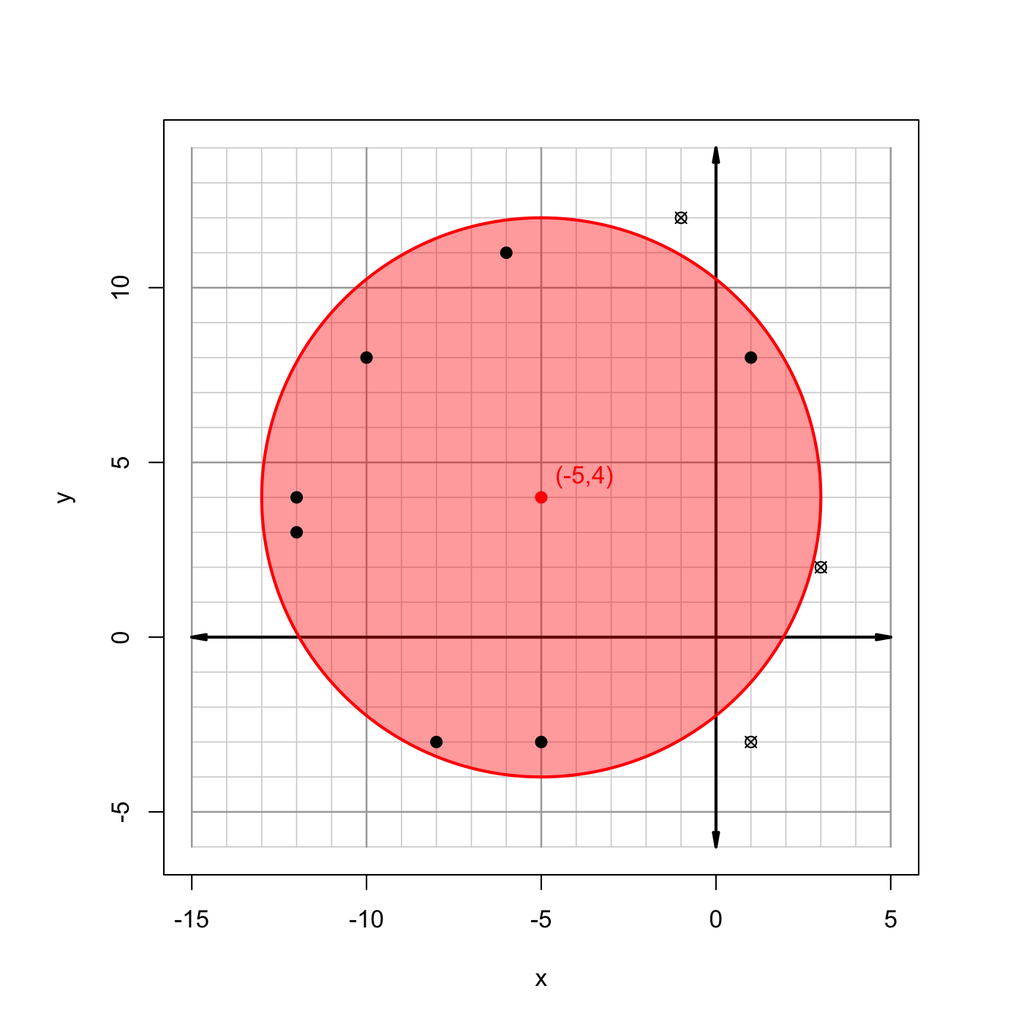

- point (1,8) is in
- point (-1,12) is NOT in
- point (-6,11) is in
- point (-10,8) is in
- point (-12,4) is in
- point (-12,3) is in
- point (-8,-3) is in
- point (-5,-3) is in
- point (1,-3) is NOT in
- point (3,2) is NOT in

Using [Desmos](https://www.desmos.com/calculator), determine which of the given points are within a distance of 12 units from point (-2, -4).

1. Graph the inequality $(x+2)^2+(y+4)^2~\le~12^2$ as the first item in Desmos.
2. Enter each point as a [Cartesian coordinate pair](https://en.wikipedia.org/wiki/Abscissa_and_ordinate). Actually, you should be able to copy/paste all the points as a single item (using commas to separate the points):
   - (9,-1), (8,1), (8,5), (1,6), (-8,6), (-13,-6), (-9,-14), (-11,-13), (-4,-15), (6,-13)
3. Click "Label" to label the points.
4. Determine which points are in the shaded area. If a point is exactly on the boundary, count that point as within the distance. You might need to zoom in on points to be sure.

(9,-1)(8,1)(8,5)(1,6)(-8,6)(-13,-6)(-9,-14)(-11,-13)(-4,-15)(6,-13)

Follow the directions given in the prompt. I've plotted the inequality and the points below, using two different marks to indicate whether the point in inside the boundary or outside the boundary. Notice the points should be listed (mostly) in a counter-clockwise order, starting from 3 o'clock (see [standard position of an angle](https://libraryguides.centennialcollege.ca/c.php?g=716824&p=5112868)).

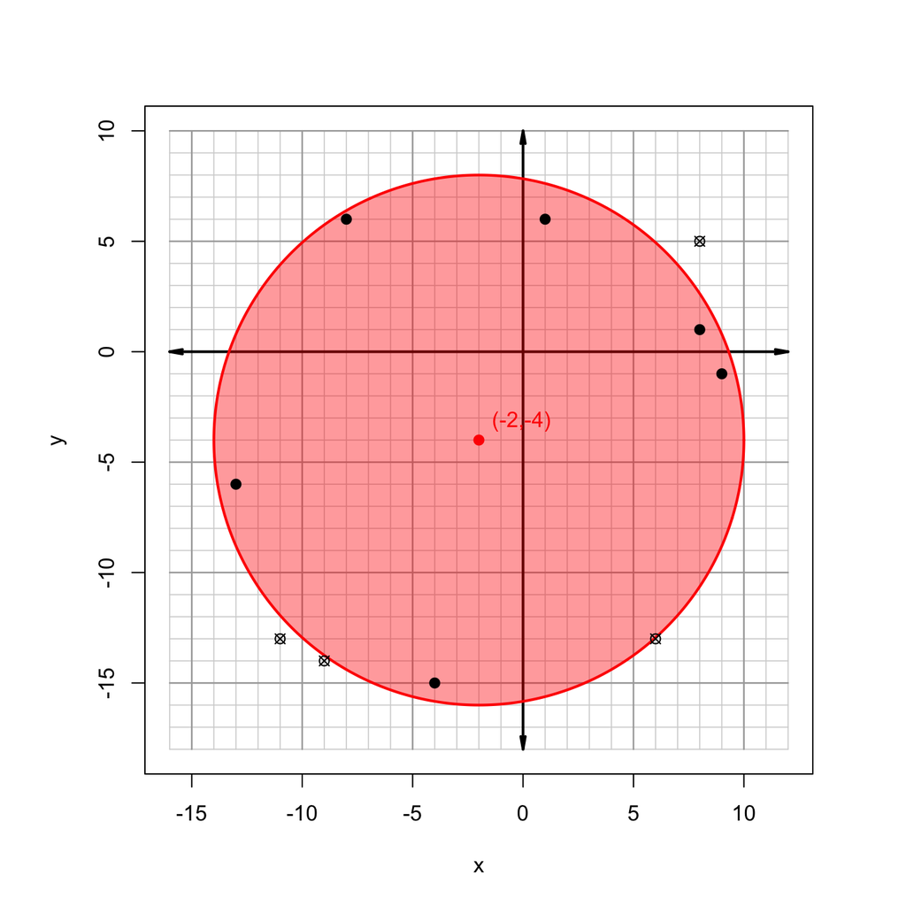

- point (9,-1) is in
- point (8,1) is in
- point (8,5) is NOT in
- point (1,6) is in
- point (-8,6) is in
- point (-13,-6) is in
- point (-9,-14) is NOT in
- point (-11,-13) is NOT in
- point (-4,-15) is in
- point (6,-13) is NOT in

Consider the points listed below:

- (16,19), (19,28), (11,25), (22,21), (18,15), (15,22), (29,32), (20,29), (25,26), (12,17)

Please determine which points satisfy both criteria below:

1. Closer than 12 units from point (22, 15), and
2. Closer than 10 units from point (18, 30).

(16,19)(19,28)(11,25)(22,21)(18,15)(15,22)(29,32)(20,29)(25,26)(12,17)

1. Open [Desmos](https://www.desmos.com/calculator).
2. As the first item, use the standard form of a circle to visualize the first criterion.
   $$(x-22)^2+(y-15)^2~\le~12^2$$
3. As the second item, use the standard form of a circle to visualize the second criterion.
   $$(x-18)^2+(y-30)^2~\le~10^2$$
4. As the third item, copy/paste the list of points. Click the "Label" checkbox.
5. Read which points are in the overlapping region.

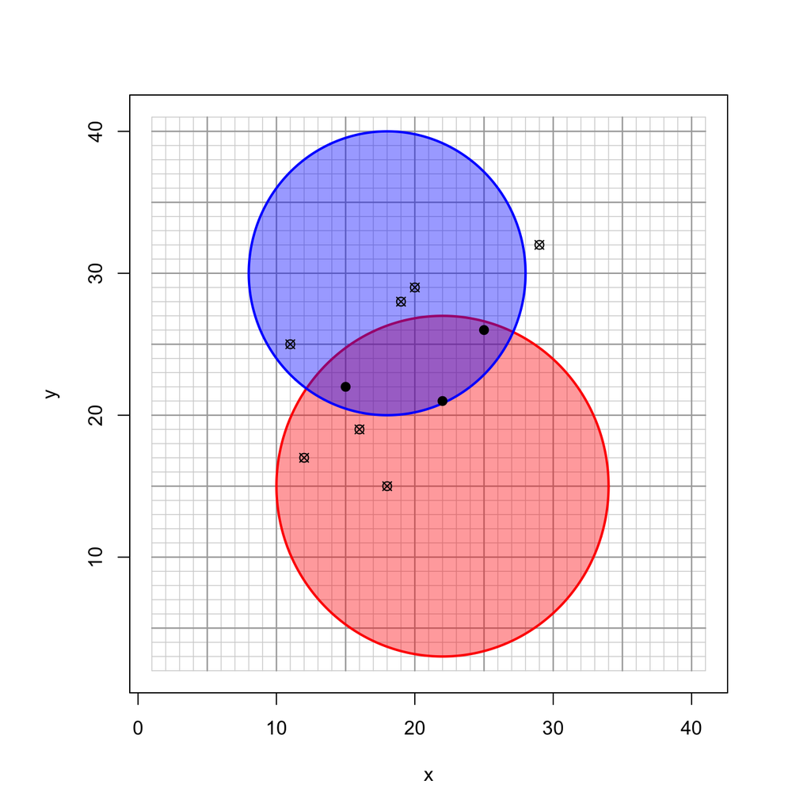

- point (16,19) is NOT in
- point (19,28) is NOT in
- point (11,25) is NOT in
- point (22,21) is in
- point (18,15) is NOT in
- point (15,22) is in
- point (29,32) is NOT in
- point (20,29) is NOT in
- point (25,26) is in
- point (12,17) is NOT in

Consider the points listed below:

- (65,21), (60,15), (53,20), (63,26), (58,18), (52,12), (67,22), (59,27), (62,25), (64,13)

Please determine which points satisfy both criteria below:

1. Closer than 21 units from point (66, 35), and
2. Closer than 9 units from point (59, 15).

(65,21)(60,15)(53,20)(63,26)(58,18)(52,12)(67,22)(59,27)(62,25)(64,13)

1. Open [Desmos](https://www.desmos.com/calculator).
2. As the first item, use the standard form of a circle to visualize the first criterion.
   $$(x-66)^2+(y-35)^2~\le~21^2$$
3. As the second item, use the standard form of a circle to visualize the second criterion.
   $$(x-59)^2+(y-15)^2~\le~9^2$$
4. As the third item, copy/paste the list of points. Click the "Label" checkbox.
5. Read which points are in the overlapping region.

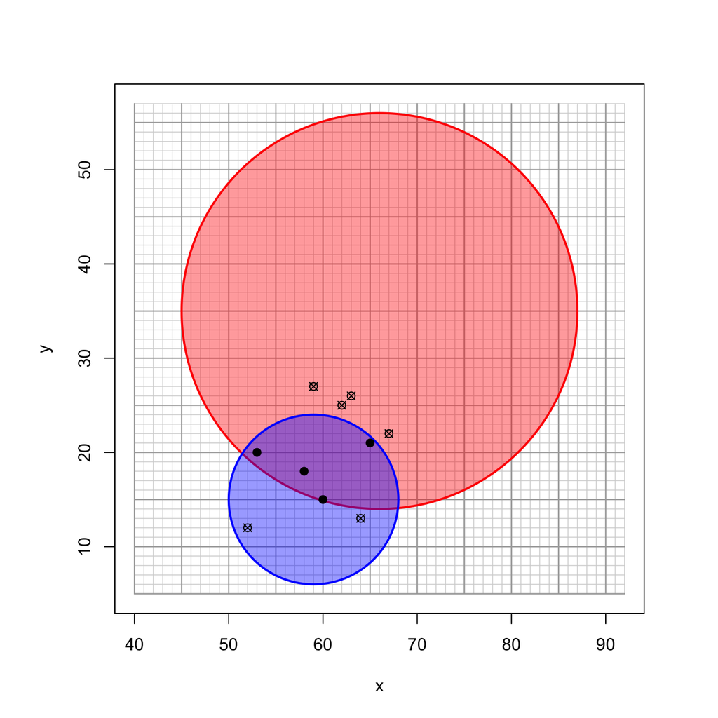

- point (65,21) is in
- point (60,15) is in
- point (53,20) is in
- point (63,26) is NOT in
- point (58,18) is in
- point (52,12) is NOT in
- point (67,22) is NOT in
- point (59,27) is NOT in
- point (62,25) is NOT in
- point (64,13) is NOT in

Consider the points listed below:

- (27,18), (32,15), (30,30), (26,24), (23,29), (24,27), (22,26), (28,12), (25,25), (17,19)

Please determine which points satisfy both criteria below:

1. Closer than 9 units from point (21, 24), and
2. Closer than 6 units from point (25, 20).

(27,18)(32,15)(30,30)(26,24)(23,29)(24,27)(22,26)(28,12)(25,25)(17,19)

1. Open [Desmos](https://www.desmos.com/calculator).
2. As the first item, use the standard form of a circle to visualize the first criterion.
   $$(x-21)^2+(y-24)^2~\le~9^2$$
3. As the second item, use the standard form of a circle to visualize the second criterion.
   $$(x-25)^2+(y-20)^2~\le~6^2$$
4. As the third item, copy/paste the list of points. Click the "Label" checkbox.
5. Read which points are in the overlapping region.

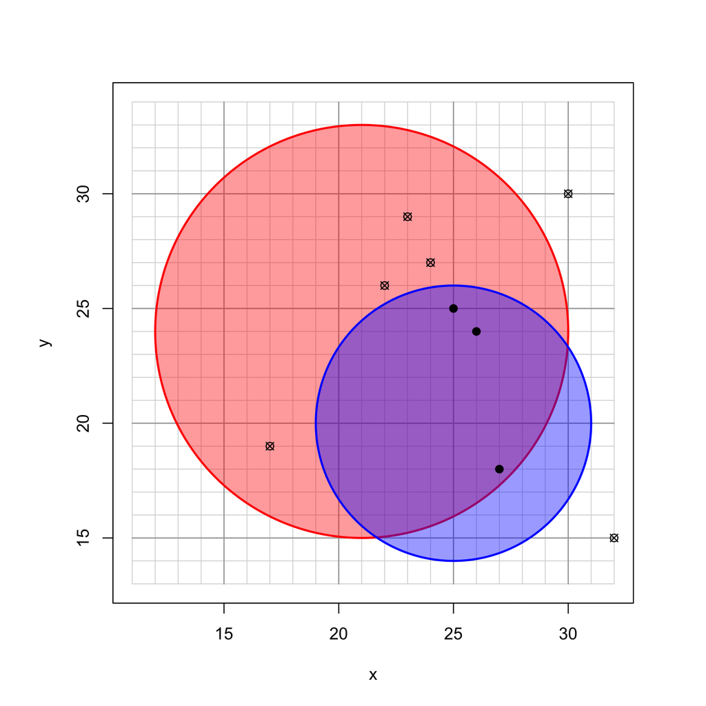

- point (27,18) is in
- point (32,15) is NOT in
- point (30,30) is NOT in
- point (26,24) is in
- point (23,29) is NOT in
- point (24,27) is NOT in
- point (22,26) is NOT in
- point (28,12) is NOT in
- point (25,25) is in
- point (17,19) is NOT in

Consider the points listed below:

- (42,45), (50,41), (51,28), (38,30), (53,39), (37,42), (43,27), (45,32), (48,29), (44,36)

Please determine which points satisfy both criteria below:

1. Closer than 18 units from point (59, 30), and
2. Closer than 19 units from point (32, 42).

(42,45)(50,41)(51,28)(38,30)(53,39)(37,42)(43,27)(45,32)(48,29)(44,36)

1. Open [Desmos](https://www.desmos.com/calculator).
2. As the first item, use the standard form of a circle to visualize the first criterion.
   $$(x-59)^2+(y-30)^2~\le~18^2$$
3. As the second item, use the standard form of a circle to visualize the second criterion.
   $$(x-32)^2+(y-42)^2~\le~19^2$$
4. As the third item, copy/paste the list of points. Click the "Label" checkbox.
5. Read which points are in the overlapping region.

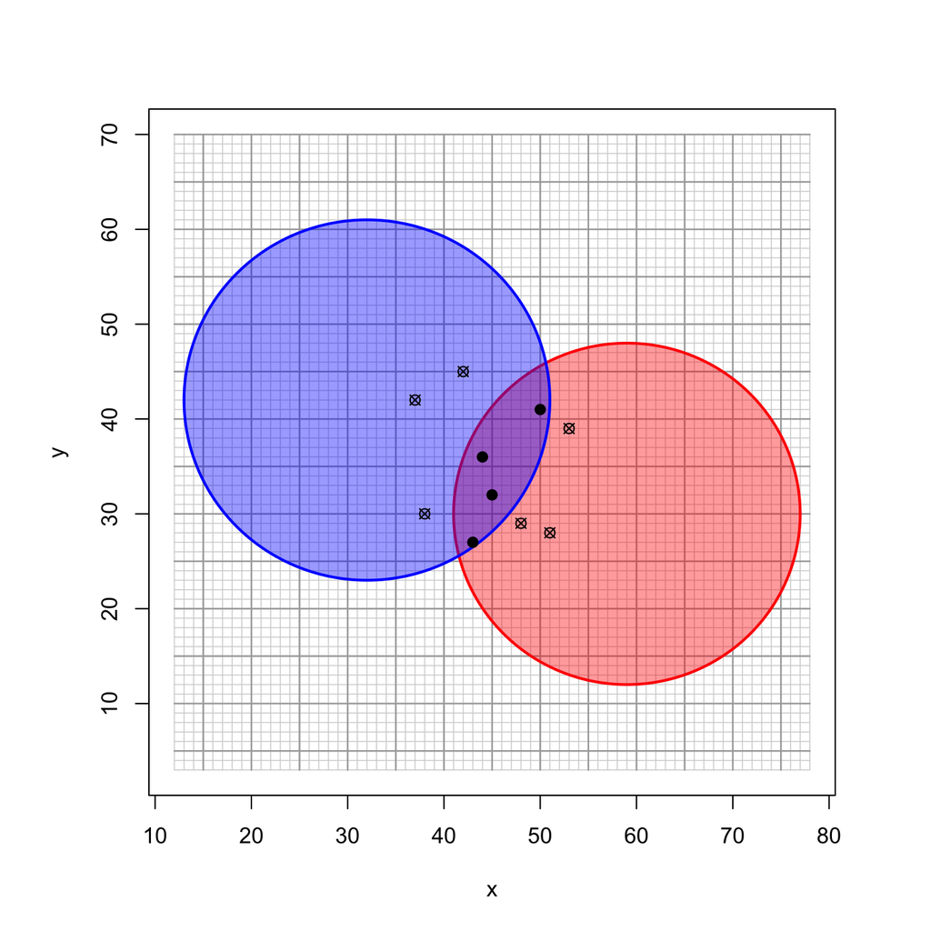

- point (42,45) is NOT in
- point (50,41) is in
- point (51,28) is NOT in
- point (38,30) is NOT in
- point (53,39) is NOT in
- point (37,42) is NOT in
- point (43,27) is in
- point (45,32) is in
- point (48,29) is NOT in
- point (44,36) is in

Consider the points listed below:

- (14,78), (24,65), (32,81), (31,80), (23,71), (17,72), (22,73), (28,79), (25,76), (21,70)

Please determine which points satisfy both criteria below:

1. Closer than 13 units from point (18, 82), and
2. Closer than 26 units from point (35, 54).

(14,78)(24,65)(32,81)(31,80)(23,71)(17,72)(22,73)(28,79)(25,76)(21,70)

1. Open [Desmos](https://www.desmos.com/calculator).
2. As the first item, use the standard form of a circle to visualize the first criterion.
   $$(x-18)^2+(y-82)^2~\le~13^2$$
3. As the second item, use the standard form of a circle to visualize the second criterion.
   $$(x-35)^2+(y-54)^2~\le~26^2$$
4. As the third item, copy/paste the list of points. Click the "Label" checkbox.
5. Read which points are in the overlapping region.

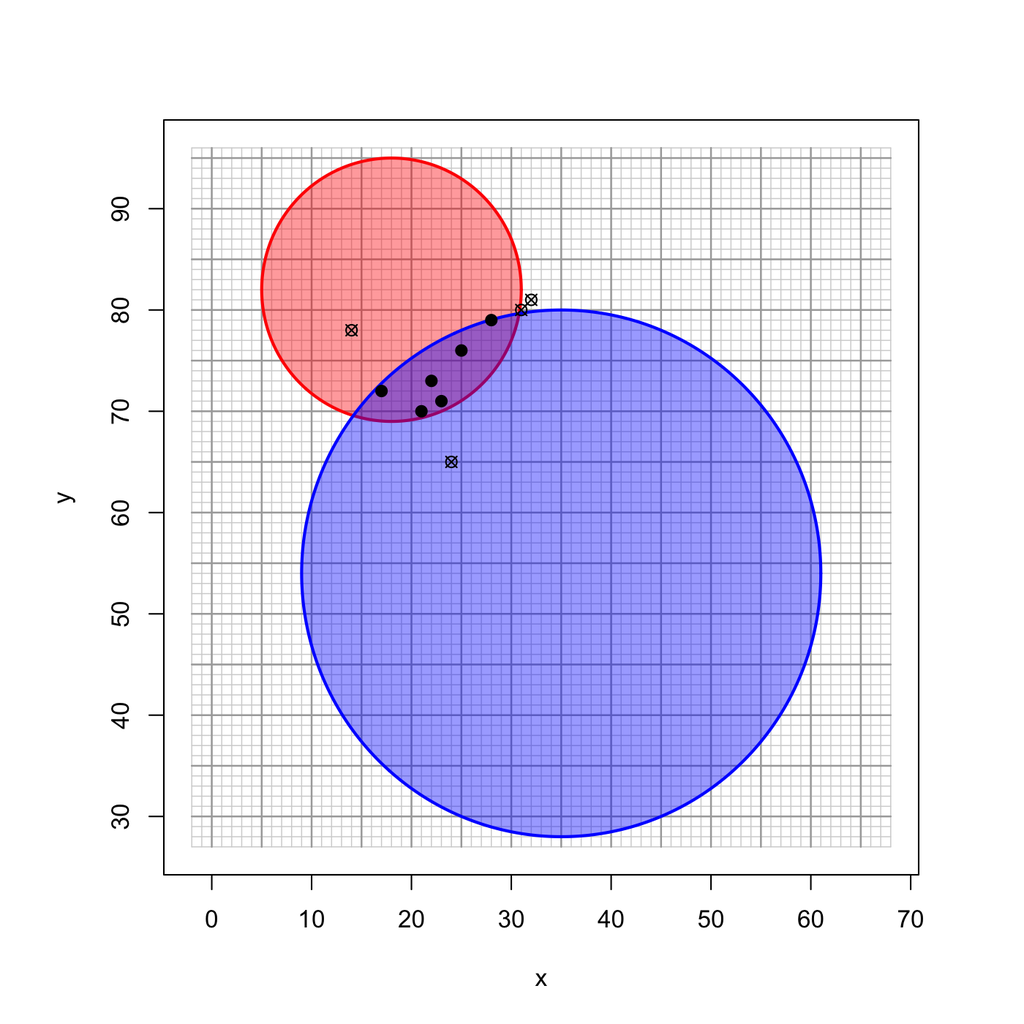

- point (14,78) is NOT in
- point (24,65) is NOT in
- point (32,81) is NOT in
- point (31,80) is NOT in
- point (23,71) is in
- point (17,72) is in
- point (22,73) is in
- point (28,79) is in
- point (25,76) is in
- point (21,70) is in

Consider the points listed below:

- (86,77), (81,73), (75,80), (90,74), (87,78), (88,79), (77,70), (85,88), (79,82), (78,86)

Please determine which points satisfy both criteria below:

1. Closer than 8 units from point (87, 82), and
2. Closer than 17 units from point (73, 69).

(86,77)(81,73)(75,80)(90,74)(87,78)(88,79)(77,70)(85,88)(79,82)(78,86)

1. Open [Desmos](https://www.desmos.com/calculator).
2. As the first item, use the standard form of a circle to visualize the first criterion.
   $$(x-87)^2+(y-82)^2~\le~8^2$$
3. As the second item, use the standard form of a circle to visualize the second criterion.
   $$(x-73)^2+(y-69)^2~\le~17^2$$
4. As the third item, copy/paste the list of points. Click the "Label" checkbox.
5. Read which points are in the overlapping region.

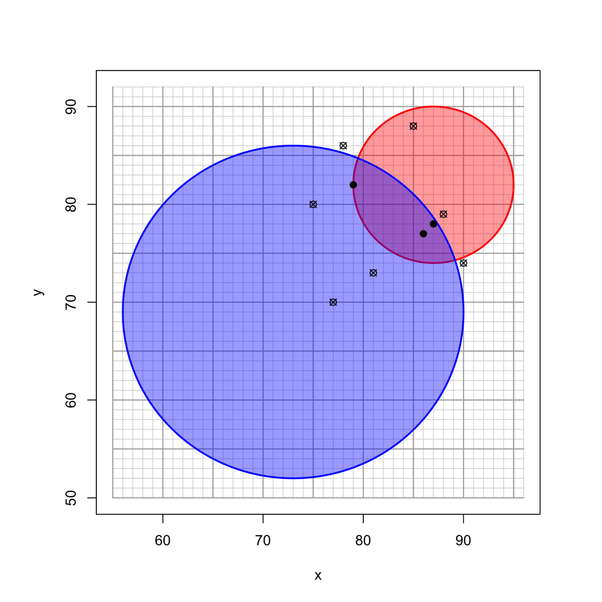

- point (86,77) is in
- point (81,73) is NOT in
- point (75,80) is NOT in
- point (90,74) is NOT in
- point (87,78) is in
- point (88,79) is NOT in
- point (77,70) is NOT in
- point (85,88) is NOT in
- point (79,82) is in
- point (78,86) is NOT in

Consider the points listed below:

- (33,53), (32,60), (42,52), (27,54), (41,55), (43,64), (35,61), (39,63), (34,58), (26,70)

Please determine which points satisfy both criteria below:

1. Closer than 11 units from point (28, 58), and
2. Closer than 17 units from point (47, 68).

(33,53)(32,60)(42,52)(27,54)(41,55)(43,64)(35,61)(39,63)(34,58)(26,70)

1. Open [Desmos](https://www.desmos.com/calculator).
2. As the first item, use the standard form of a circle to visualize the first criterion.
   $$(x-28)^2+(y-58)^2~\le~11^2$$
3. As the second item, use the standard form of a circle to visualize the second criterion.
   $$(x-47)^2+(y-68)^2~\le~17^2$$
4. As the third item, copy/paste the list of points. Click the "Label" checkbox.
5. Read which points are in the overlapping region.

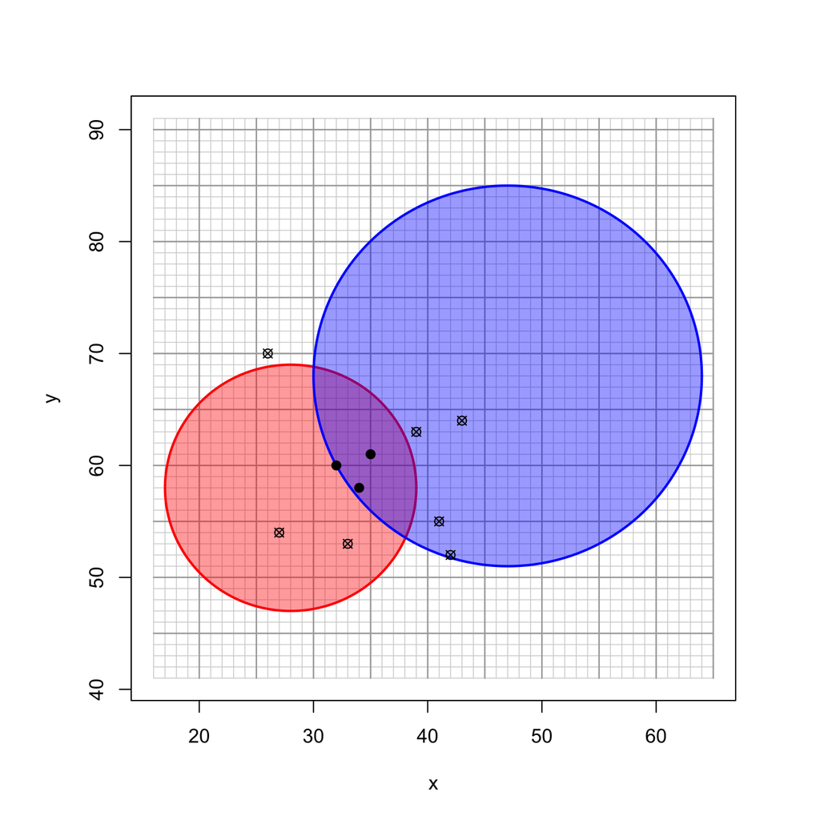

- point (33,53) is NOT in
- point (32,60) is in
- point (42,52) is NOT in
- point (27,54) is NOT in
- point (41,55) is NOT in
- point (43,64) is NOT in
- point (35,61) is in
- point (39,63) is NOT in
- point (34,58) is in
- point (26,70) is NOT in

Consider the points listed below:

- (75,64), (63,74), (70,71), (72,73), (67,66), (65,70), (78,79), (71,65), (73,77), (64,78)

Please determine which points satisfy both criteria below:

1. Closer than 14 units from point (81, 72), and
2. Closer than 15 units from point (59, 68).

(75,64)(63,74)(70,71)(72,73)(67,66)(65,70)(78,79)(71,65)(73,77)(64,78)

1. Open [Desmos](https://www.desmos.com/calculator).
2. As the first item, use the standard form of a circle to visualize the first criterion.
   $$(x-81)^2+(y-72)^2~\le~14^2$$
3. As the second item, use the standard form of a circle to visualize the second criterion.
   $$(x-59)^2+(y-68)^2~\le~15^2$$
4. As the third item, copy/paste the list of points. Click the "Label" checkbox.
5. Read which points are in the overlapping region.

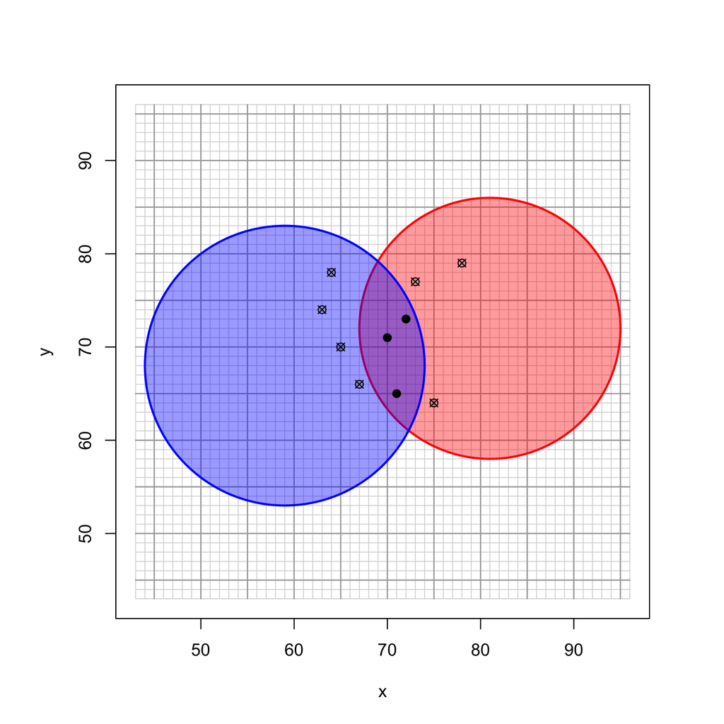

- point (75,64) is NOT in
- point (63,74) is NOT in
- point (70,71) is in
- point (72,73) is in
- point (67,66) is NOT in
- point (65,70) is NOT in
- point (78,79) is NOT in
- point (71,65) is in
- point (73,77) is NOT in
- point (64,78) is NOT in

Consider the points listed below:

- (42,52), (34,54), (33,60), (38,46), (35,62), (43,47), (47,55), (48,56), (32,45), (30,49)

Please determine which points satisfy both criteria below:

1. Closer than 23 units from point (34, 72), and
2. Closer than 23 units from point (45, 35).

(42,52)(34,54)(33,60)(38,46)(35,62)(43,47)(47,55)(48,56)(32,45)(30,49)

1. Open [Desmos](https://www.desmos.com/calculator).
2. As the first item, use the standard form of a circle to visualize the first criterion.
   $$(x-34)^2+(y-72)^2~\le~23^2$$
3. As the second item, use the standard form of a circle to visualize the second criterion.
   $$(x-45)^2+(y-35)^2~\le~23^2$$
4. As the third item, copy/paste the list of points. Click the "Label" checkbox.
5. Read which points are in the overlapping region.

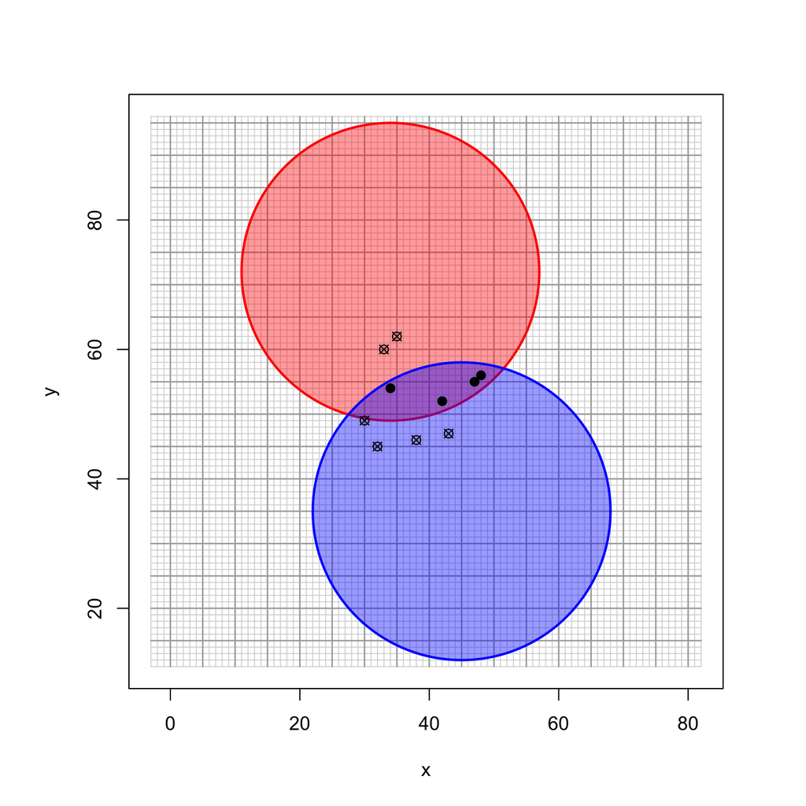

- point (42,52) is in
- point (34,54) is in
- point (33,60) is NOT in
- point (38,46) is NOT in
- point (35,62) is NOT in
- point (43,47) is NOT in
- point (47,55) is in
- point (48,56) is in
- point (32,45) is NOT in
- point (30,49) is NOT in

Consider the points listed below:

- (47,70), (40,66), (48,75), (35,61), (38,67), (41,65), (46,68), (42,62), (45,78), (52,60)

Please determine which points satisfy both criteria below:

1. Closer than 17 units from point (48, 80), and
2. Closer than 26 units from point (35, 47).

(47,70)(40,66)(48,75)(35,61)(38,67)(41,65)(46,68)(42,62)(45,78)(52,60)

1. Open [Desmos](https://www.desmos.com/calculator).
2. As the first item, use the standard form of a circle to visualize the first criterion.
   $$(x-48)^2+(y-80)^2~\le~17^2$$
3. As the second item, use the standard form of a circle to visualize the second criterion.
   $$(x-35)^2+(y-47)^2~\le~26^2$$
4. As the third item, copy/paste the list of points. Click the "Label" checkbox.
5. Read which points are in the overlapping region.

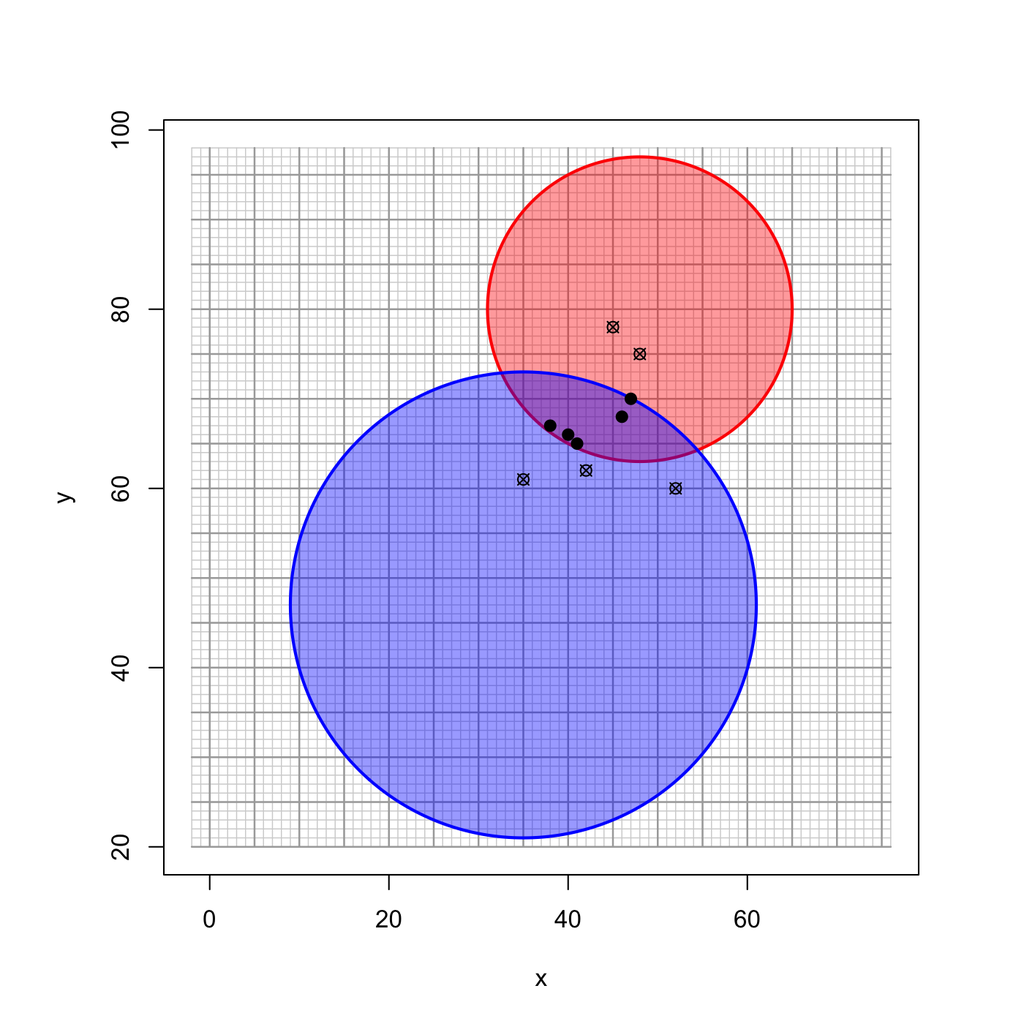

- point (47,70) is in
- point (40,66) is in
- point (48,75) is NOT in
- point (35,61) is NOT in
- point (38,67) is in
- point (41,65) is in
- point (46,68) is in
- point (42,62) is NOT in
- point (45,78) is NOT in
- point (52,60) is NOT in

A circle has a center and a radius. The distance from the center to any point on the edge equals the radius.

In Desmos, we can graph a circle using an equation that looks like [the Pythagorean equation](https://en.wikipedia.org/wiki/Pythagorean_theorem) and the [2D distance formula](https://en.wikipedia.org/wiki/Euclidean_distance#Two_dimensions). If the center is at $(h,k)$ and the radius equals $r$, the following equation graphs the desired circle in an $xy$-plane.

$$(x-h)^2+(y-k)^2~=~r^2$$

A large square lake is 200 miles across. The positions of 3 lighthouses are known, as well as the distance from each lighthouse to a boat.

| lighthouse | position (miles, miles) | distance to boat (miles) |
| --- | --- | --- |
| 1 | $(107,184)$ | $85$ |
| 2 | $(124,172)$ | $78$ |
| 3 | $(62,124)$ | $40$ |

Use [trilateration](https://en.wikipedia.org/wiki/Trilateration) to find the position of the boat:

(, )

In Desmos, graph the following:

$$(x-107)^2+(y-184)^2=85^2$$
$$(x-124)^2+(y-172)^2=78^2$$
$$(x-62)^2+(y-124)^2=40^2$$

Zoom out to see from 0 to 200 on both axes. Find where all three circles intersect by clicking.

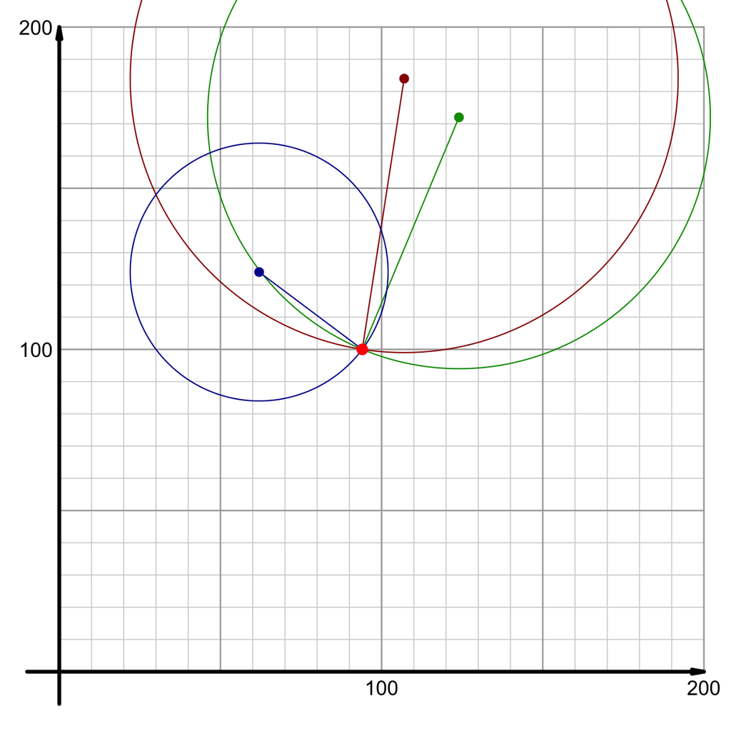

All three circles intersect at point (94, 100).

A circle has a center and a radius. The distance from the center to any point on the edge equals the radius.

In Desmos, we can graph a circle using an equation that looks like [the Pythagorean equation](https://en.wikipedia.org/wiki/Pythagorean_theorem) and the [2D distance formula](https://en.wikipedia.org/wiki/Euclidean_distance#Two_dimensions). If the center is at $(h,k)$ and the radius equals $r$, the following equation graphs the desired circle in an $xy$-plane.

$$(x-h)^2+(y-k)^2~=~r^2$$

A large square lake is 200 miles across. The positions of 3 lighthouses are known, as well as the distance from each lighthouse to a boat.

| lighthouse | position (miles, miles) | distance to boat (miles) |
| --- | --- | --- |
| 1 | $(70,82)$ | $39$ |
| 2 | $(46,177)$ | $100$ |
| 3 | $(118,81)$ | $20$ |

Use [trilateration](https://en.wikipedia.org/wiki/Trilateration) to find the position of the boat:

(, )

In Desmos, graph the following:

$$(x-70)^2+(y-82)^2=39^2$$
$$(x-46)^2+(y-177)^2=100^2$$
$$(x-118)^2+(y-81)^2=20^2$$

Zoom out to see from 0 to 200 on both axes. Find where all three circles intersect by clicking.

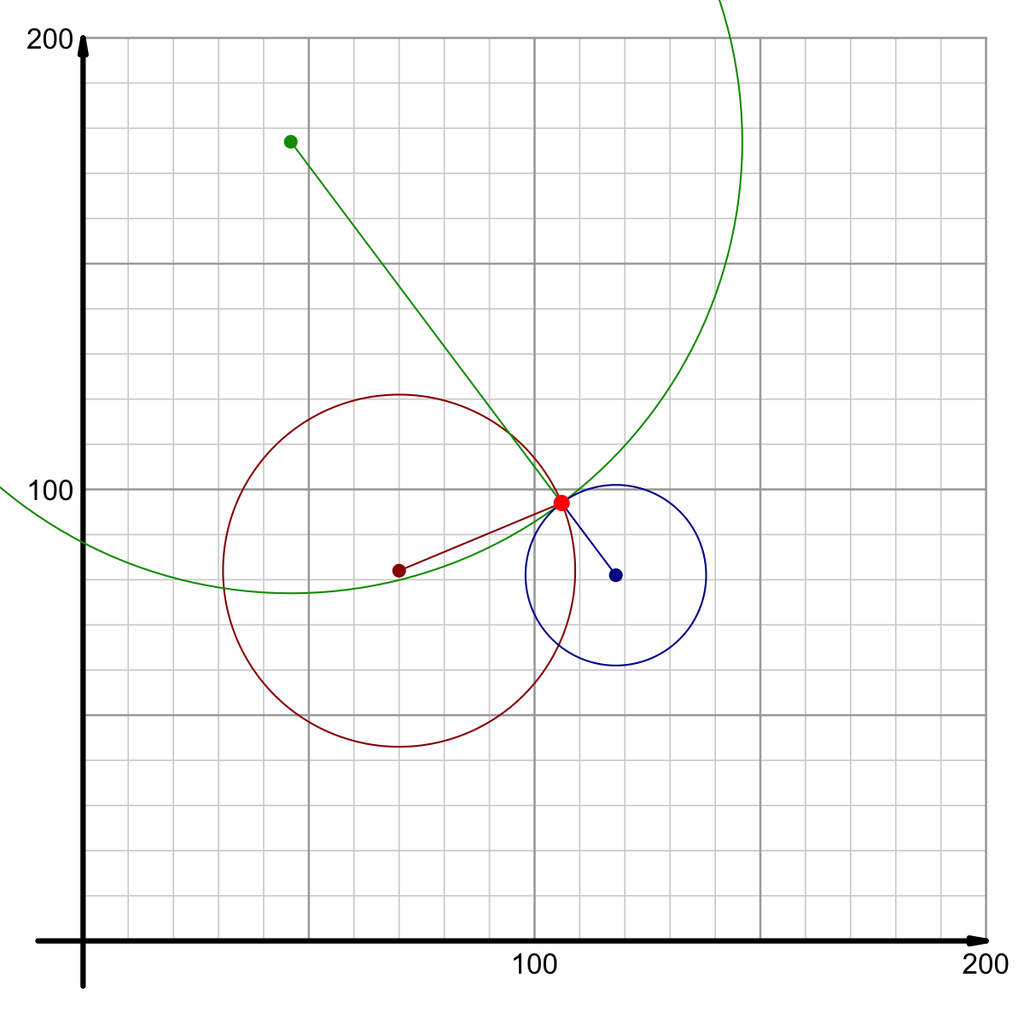

All three circles intersect at point (106, 97).

A circle has a center and a radius. The distance from the center to any point on the edge equals the radius.

In Desmos, we can graph a circle using an equation that looks like [the Pythagorean equation](https://en.wikipedia.org/wiki/Pythagorean_theorem) and the [2D distance formula](https://en.wikipedia.org/wiki/Euclidean_distance#Two_dimensions). If the center is at $(h,k)$ and the radius equals $r$, the following equation graphs the desired circle in an $xy$-plane.

$$(x-h)^2+(y-k)^2~=~r^2$$

A large square lake is 200 miles across. The positions of 3 lighthouses are known, as well as the distance from each lighthouse to a boat.

| lighthouse | position (miles, miles) | distance to boat (miles) |
| --- | --- | --- |
| 1 | $(61,43)$ | $60$ |
| 2 | $(37,28)$ | $87$ |
| 3 | $(27,115)$ | $74$ |

Use [trilateration](https://en.wikipedia.org/wiki/Trilateration) to find the position of the boat:

(, )

In Desmos, graph the following:

$$(x-61)^2+(y-43)^2=60^2$$
$$(x-37)^2+(y-28)^2=87^2$$
$$(x-27)^2+(y-115)^2=74^2$$

Zoom out to see from 0 to 200 on both axes. Find where all three circles intersect by clicking.

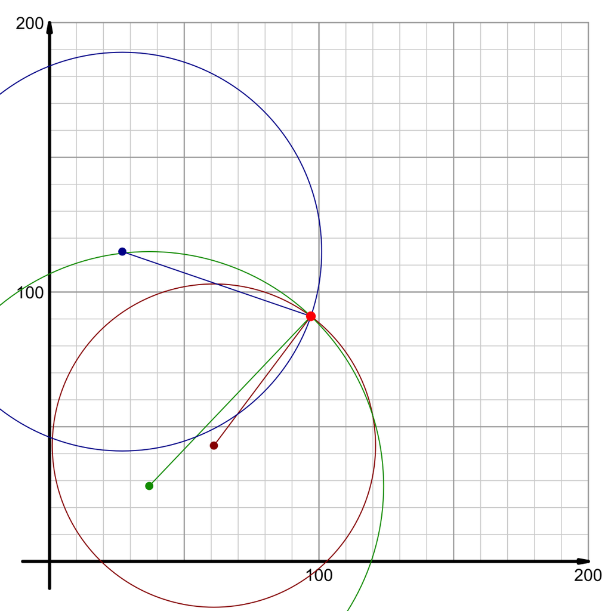

All three circles intersect at point (97, 91).

A circle has a center and a radius. The distance from the center to any point on the edge equals the radius.

In Desmos, we can graph a circle using an equation that looks like [the Pythagorean equation](https://en.wikipedia.org/wiki/Pythagorean_theorem) and the [2D distance formula](https://en.wikipedia.org/wiki/Euclidean_distance#Two_dimensions). If the center is at $(h,k)$ and the radius equals $r$, the following equation graphs the desired circle in an $xy$-plane.

$$(x-h)^2+(y-k)^2~=~r^2$$

A large square lake is 200 miles across. The positions of 3 lighthouses are known, as well as the distance from each lighthouse to a boat.

| lighthouse | position (miles, miles) | distance to boat (miles) |
| --- | --- | --- |
| 1 | $(133,52)$ | $58$ |
| 2 | $(16,132)$ | $85$ |
| 3 | $(11,53)$ | $89$ |

Use [trilateration](https://en.wikipedia.org/wiki/Trilateration) to find the position of the boat:

(, )

In Desmos, graph the following:

$$(x-133)^2+(y-52)^2=58^2$$
$$(x-16)^2+(y-132)^2=85^2$$
$$(x-11)^2+(y-53)^2=89^2$$

Zoom out to see from 0 to 200 on both axes. Find where all three circles intersect by clicking.

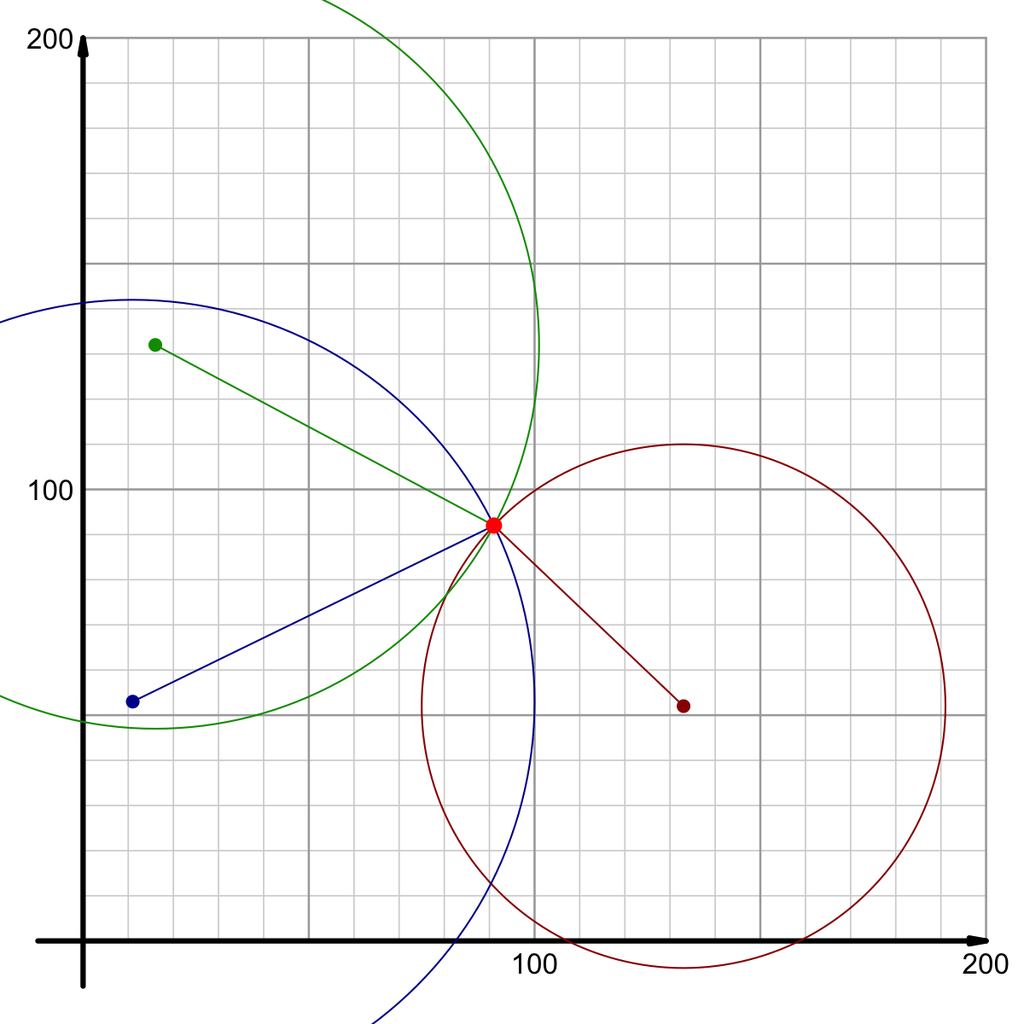

All three circles intersect at point (91, 92).

A circle has a center and a radius. The distance from the center to any point on the edge equals the radius.

In Desmos, we can graph a circle using an equation that looks like [the Pythagorean equation](https://en.wikipedia.org/wiki/Pythagorean_theorem) and the [2D distance formula](https://en.wikipedia.org/wiki/Euclidean_distance#Two_dimensions). If the center is at $(h,k)$ and the radius equals $r$, the following equation graphs the desired circle in an $xy$-plane.

$$(x-h)^2+(y-k)^2~=~r^2$$

A large square lake is 200 miles across. The positions of 3 lighthouses are known, as well as the distance from each lighthouse to a boat.

| lighthouse | position (miles, miles) | distance to boat (miles) |
| --- | --- | --- |
| 1 | $(119,111)$ | $13$ |
| 2 | $(95,90)$ | $20$ |
| 3 | $(167,61)$ | $75$ |

Use [trilateration](https://en.wikipedia.org/wiki/Trilateration) to find the position of the boat:

(, )

In Desmos, graph the following:

$$(x-119)^2+(y-111)^2=13^2$$
$$(x-95)^2+(y-90)^2=20^2$$
$$(x-167)^2+(y-61)^2=75^2$$

Zoom out to see from 0 to 200 on both axes. Find where all three circles intersect by clicking.

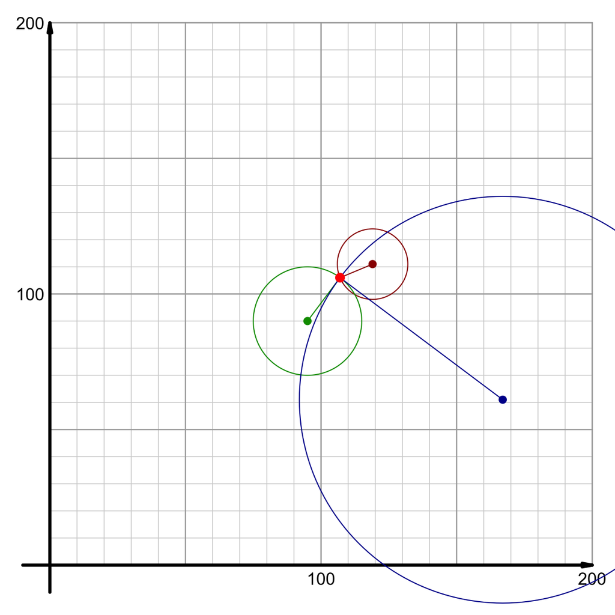

All three circles intersect at point (107, 106).

A circle has a center and a radius. The distance from the center to any point on the edge equals the radius.

In Desmos, we can graph a circle using an equation that looks like [the Pythagorean equation](https://en.wikipedia.org/wiki/Pythagorean_theorem) and the [2D distance formula](https://en.wikipedia.org/wiki/Euclidean_distance#Two_dimensions). If the center is at $(h,k)$ and the radius equals $r$, the following equation graphs the desired circle in an $xy$-plane.

$$(x-h)^2+(y-k)^2~=~r^2$$

A large square lake is 200 miles across. The positions of 3 lighthouses are known, as well as the distance from each lighthouse to a boat.

| lighthouse | position (miles, miles) | distance to boat (miles) |
| --- | --- | --- |
| 1 | $(24,159)$ | $85$ |
| 2 | $(125,152)$ | $55$ |
| 3 | $(104,113)$ | $13$ |

Use [trilateration](https://en.wikipedia.org/wiki/Trilateration) to find the position of the boat:

(, )

In Desmos, graph the following:

$$(x-24)^2+(y-159)^2=85^2$$
$$(x-125)^2+(y-152)^2=55^2$$
$$(x-104)^2+(y-113)^2=13^2$$

Zoom out to see from 0 to 200 on both axes. Find where all three circles intersect by clicking.

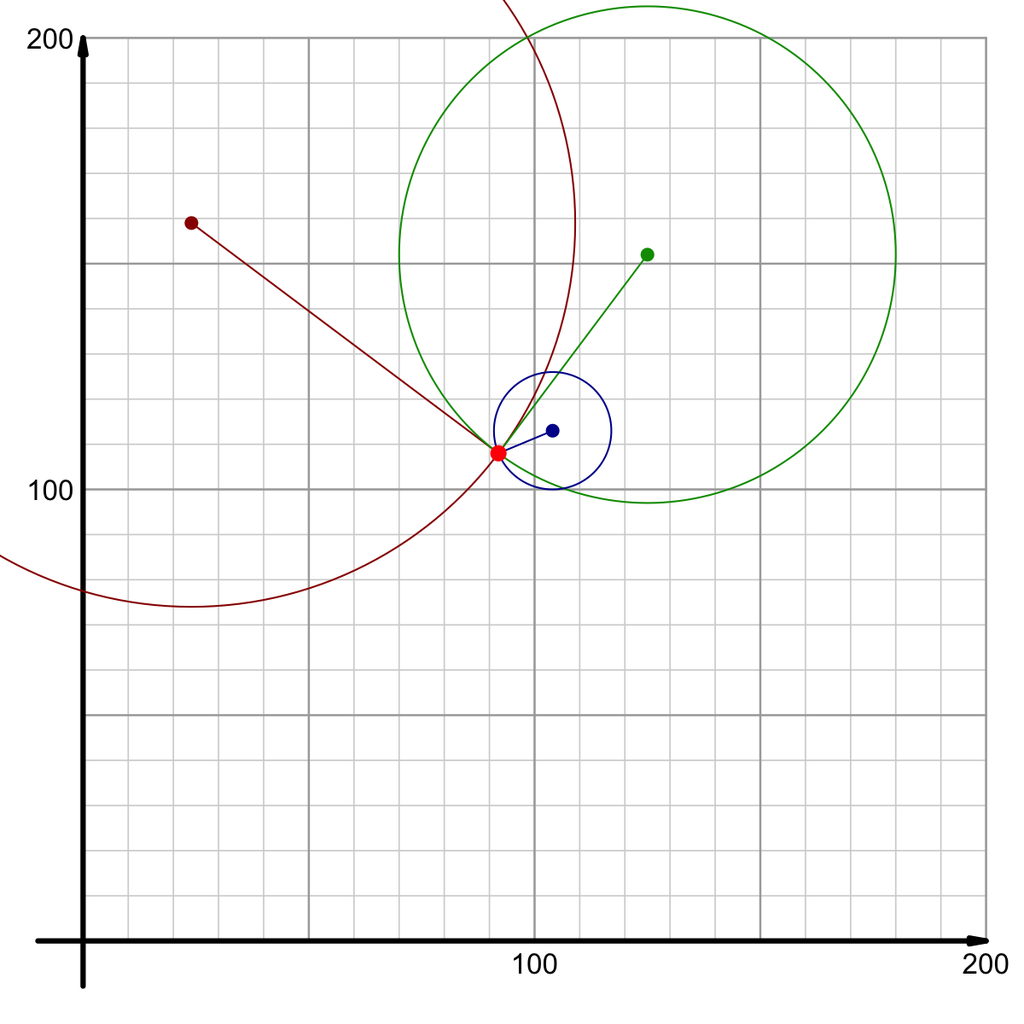

All three circles intersect at point (92, 108).

A circle has a center and a radius. The distance from the center to any point on the edge equals the radius.

In Desmos, we can graph a circle using an equation that looks like [the Pythagorean equation](https://en.wikipedia.org/wiki/Pythagorean_theorem) and the [2D distance formula](https://en.wikipedia.org/wiki/Euclidean_distance#Two_dimensions). If the center is at $(h,k)$ and the radius equals $r$, the following equation graphs the desired circle in an $xy$-plane.

$$(x-h)^2+(y-k)^2~=~r^2$$

A large square lake is 200 miles across. The positions of 3 lighthouses are known, as well as the distance from each lighthouse to a boat.

| lighthouse | position (miles, miles) | distance to boat (miles) |
| --- | --- | --- |
| 1 | $(37,126)$ | $75$ |
| 2 | $(76,149)$ | $55$ |
| 3 | $(123,57)$ | $50$ |

Use [trilateration](https://en.wikipedia.org/wiki/Trilateration) to find the position of the boat:

In Desmos, graph the following:

$$(x-37)^2+(y-126)^2=75^2$$
$$(x-76)^2+(y-149)^2=55^2$$
$$(x-123)^2+(y-57)^2=50^2$$

Zoom out to see from 0 to 200 on both axes. Find where all three circles intersect by clicking.

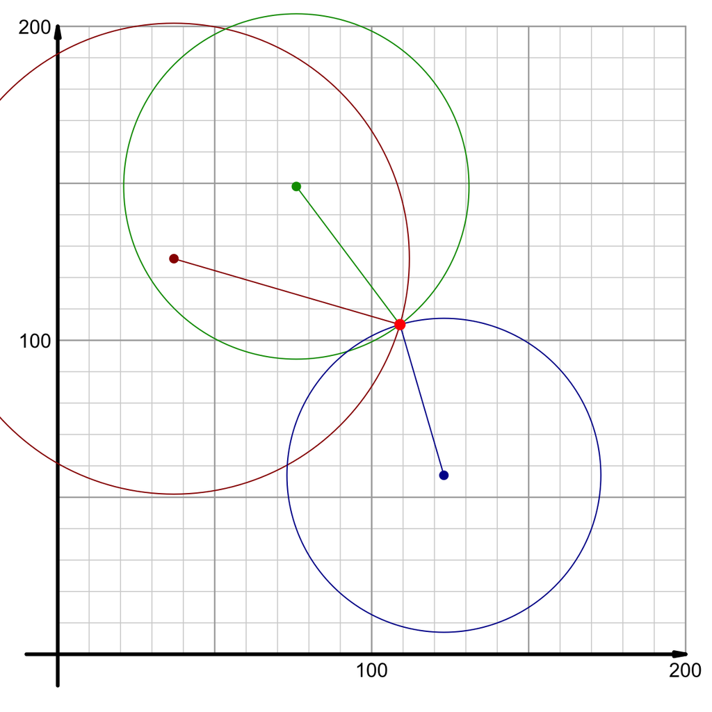

All three circles intersect at point (109, 105).

A circle has a center and a radius. The distance from the center to any point on the edge equals the radius.

In Desmos, we can graph a circle using an equation that looks like [the Pythagorean equation](https://en.wikipedia.org/wiki/Pythagorean_theorem) and the [2D distance formula](https://en.wikipedia.org/wiki/Euclidean_distance#Two_dimensions). If the center is at $(h,k)$ and the radius equals $r$, the following equation graphs the desired circle in an $xy$-plane.

$$(x-h)^2+(y-k)^2~=~r^2$$

A large square lake is 200 miles across. The positions of 3 lighthouses are known, as well as the distance from each lighthouse to a boat.

| lighthouse | position (miles, miles) | distance to boat (miles) |
| --- | --- | --- |
| 1 | $(75,116)$ | $26$ |
| 2 | $(83,43)$ | $65$ |
| 3 | $(167,157)$ | $85$ |

Use [trilateration](https://en.wikipedia.org/wiki/Trilateration) to find the position of the boat:

In Desmos, graph the following:

$$(x-75)^2+(y-116)^2=26^2$$
$$(x-83)^2+(y-43)^2=65^2$$
$$(x-167)^2+(y-157)^2=85^2$$

Zoom out to see from 0 to 200 on both axes. Find where all three circles intersect by clicking.

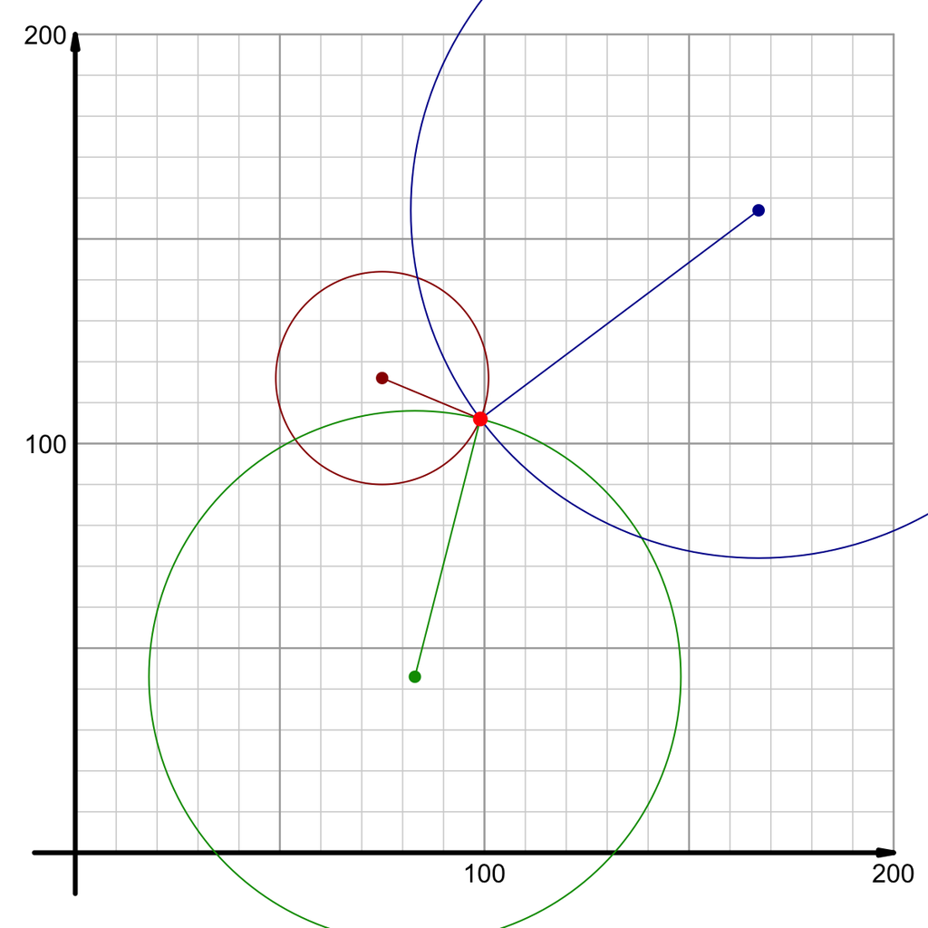

All three circles intersect at point (99, 106).

A circle has a center and a radius. The distance from the center to any point on the edge equals the radius.

In Desmos, we can graph a circle using an equation that looks like [the Pythagorean equation](https://en.wikipedia.org/wiki/Pythagorean_theorem) and the [2D distance formula](https://en.wikipedia.org/wiki/Euclidean_distance#Two_dimensions). If the center is at $(h,k)$ and the radius equals $r$, the following equation graphs the desired circle in an $xy$-plane.

$$(x-h)^2+(y-k)^2~=~r^2$$

A large square lake is 200 miles across. The positions of 3 lighthouses are known, as well as the distance from each lighthouse to a boat.

| lighthouse | position (miles, miles) | distance to boat (miles) |
| --- | --- | --- |
| 1 | $(95,68)$ | $37$ |
| 2 | $(163,61)$ | $70$ |
| 3 | $(50,179)$ | $95$ |

Use [trilateration](https://en.wikipedia.org/wiki/Trilateration) to find the position of the boat:

In Desmos, graph the following:

$$(x-95)^2+(y-68)^2=37^2$$
$$(x-163)^2+(y-61)^2=70^2$$
$$(x-50)^2+(y-179)^2=95^2$$

Zoom out to see from 0 to 200 on both axes. Find where all three circles intersect by clicking.

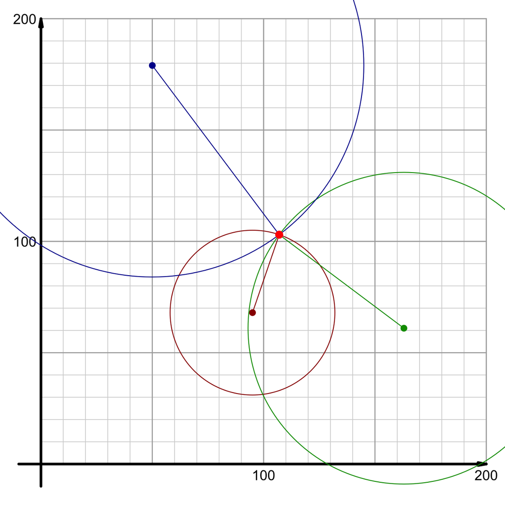

All three circles intersect at point (107, 103).

A circle has a center and a radius. The distance from the center to any point on the edge equals the radius.

In Desmos, we can graph a circle using an equation that looks like [the Pythagorean equation](https://en.wikipedia.org/wiki/Pythagorean_theorem) and the [2D distance formula](https://en.wikipedia.org/wiki/Euclidean_distance#Two_dimensions). If the center is at $(h,k)$ and the radius equals $r$, the following equation graphs the desired circle in an $xy$-plane.

$$(x-h)^2+(y-k)^2~=~r^2$$

A large square lake is 200 miles across. The positions of 3 lighthouses are known, as well as the distance from each lighthouse to a boat.

| lighthouse | position (miles, miles) | distance to boat (miles) |
| --- | --- | --- |
| 1 | $(149,173)$ | $85$ |
| 2 | $(61,84)$ | $50$ |
| 3 | $(113,95)$ | $5$ |

Use [trilateration](https://en.wikipedia.org/wiki/Trilateration) to find the position of the boat:

In Desmos, graph the following:

$$(x-149)^2+(y-173)^2=85^2$$
$$(x-61)^2+(y-84)^2=50^2$$
$$(x-113)^2+(y-95)^2=5^2$$

Zoom out to see from 0 to 200 on both axes. Find where all three circles intersect by clicking.

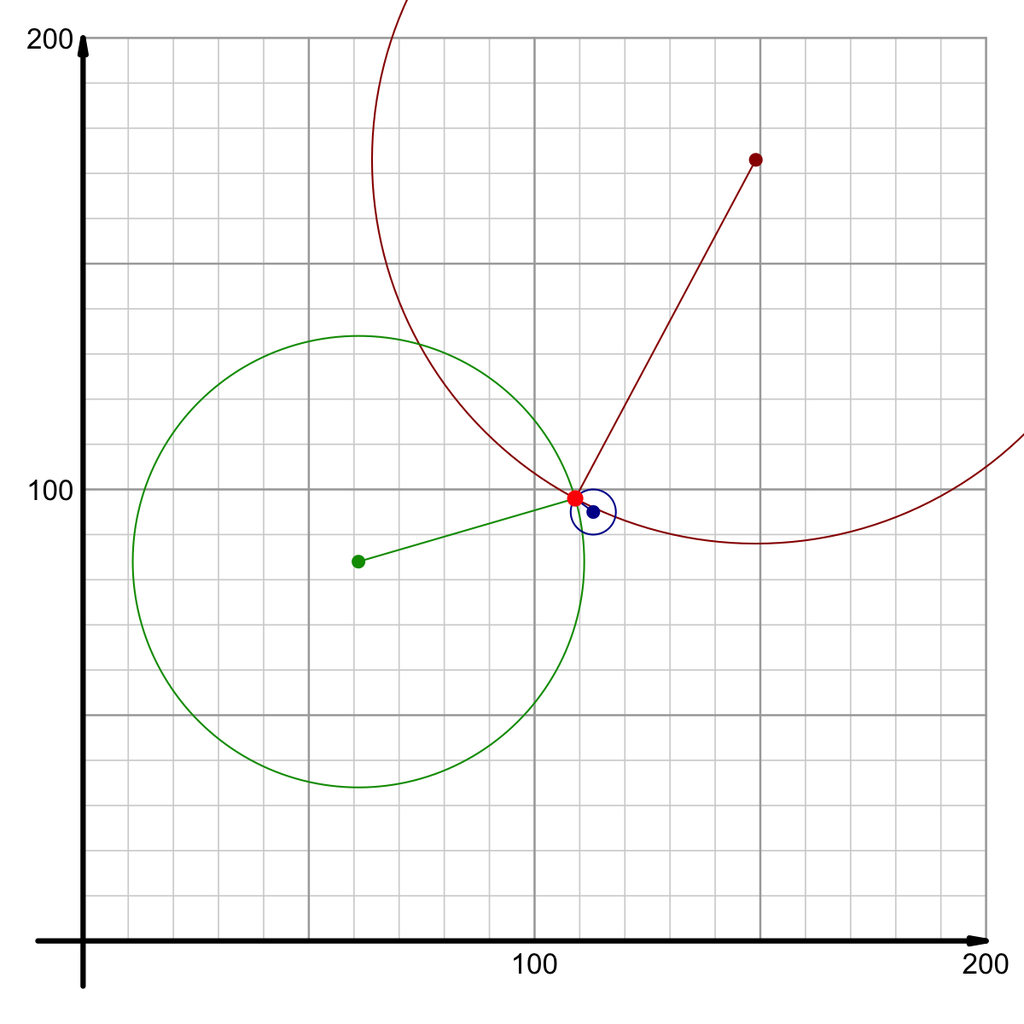

All three circles intersect at point (109, 98).

A [right rectangular prism](https://en.m.wikipedia.org/wiki/Rectangular_cuboid) is 10 inches wide, 6 inches deep, and 16 inches tall.

What is the distance between opposite corners?

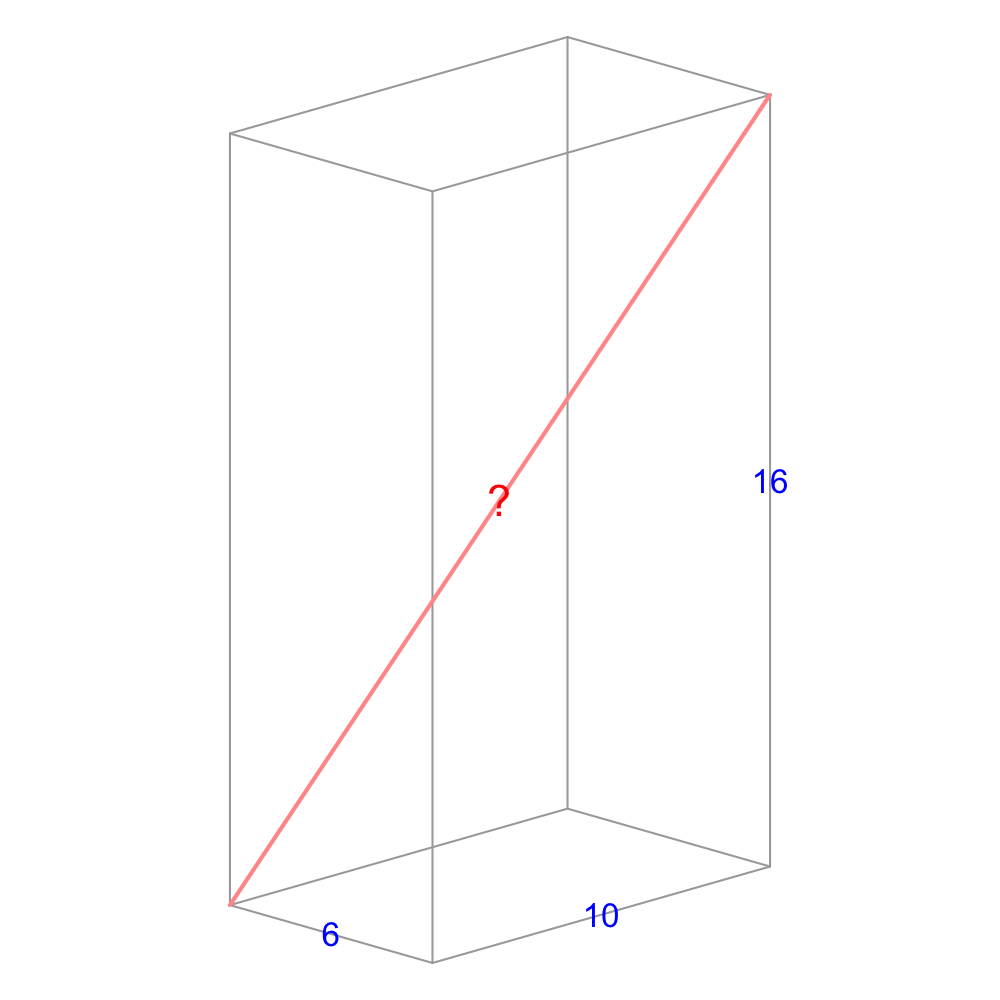

Please be accurate within $\pm$ 0.01 of the exact answer.

Let's use Pythagorean Theorem. This is possible because all angles are 90 degrees. To do this, we can first find the length of a diagonal across the bottom. Let's call it $B$.

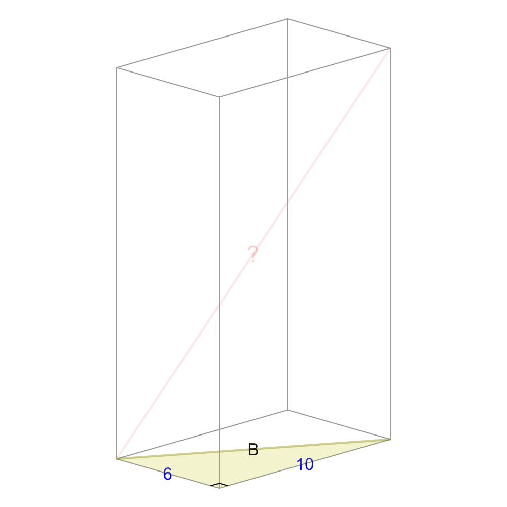

$$B~=~\sqrt{10^2+6^2}~=~\sqrt{136}
~\approx~11.6619038$$

Now we can form another **right triangle**, using $B$, the height, and the desired length, which we can call $D$.

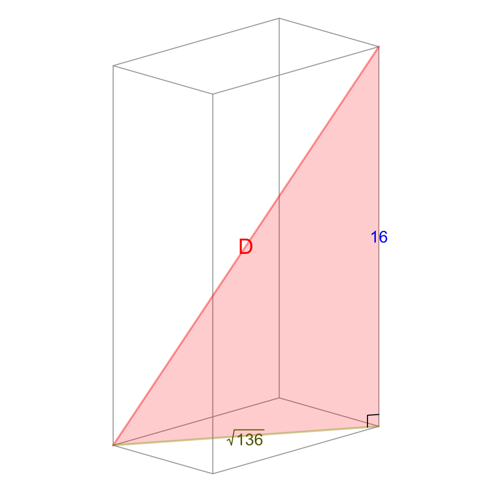

$$D ~=~
\sqrt{16^2+\left(\sqrt{136}\right)^2}$$
$$D ~=~ \sqrt{256+136}$$
$$D ~=~ \sqrt{392}$$
$$D ~\approx~ 19.7989899$$

If you were super observant, you might have picked up on a shortcut. Basically, in 3D, [the distance](https://en.wikipedia.org/wiki/Distance#Straight-line_or_Euclidean_distance) between 2 points is:

$$D~=~\sqrt{(\Delta x)^2+(\Delta
y)^2+(\Delta z)^2}$$

where $\Delta x=x_2-x_1$ and $\Delta y=y_2-y_1$ and $\Delta z=z_2-z_1$.

A [right rectangular prism](https://en.m.wikipedia.org/wiki/Rectangular_cuboid) is 19 inches wide, 13 inches deep, and 11 inches tall.

What is the distance between opposite corners?

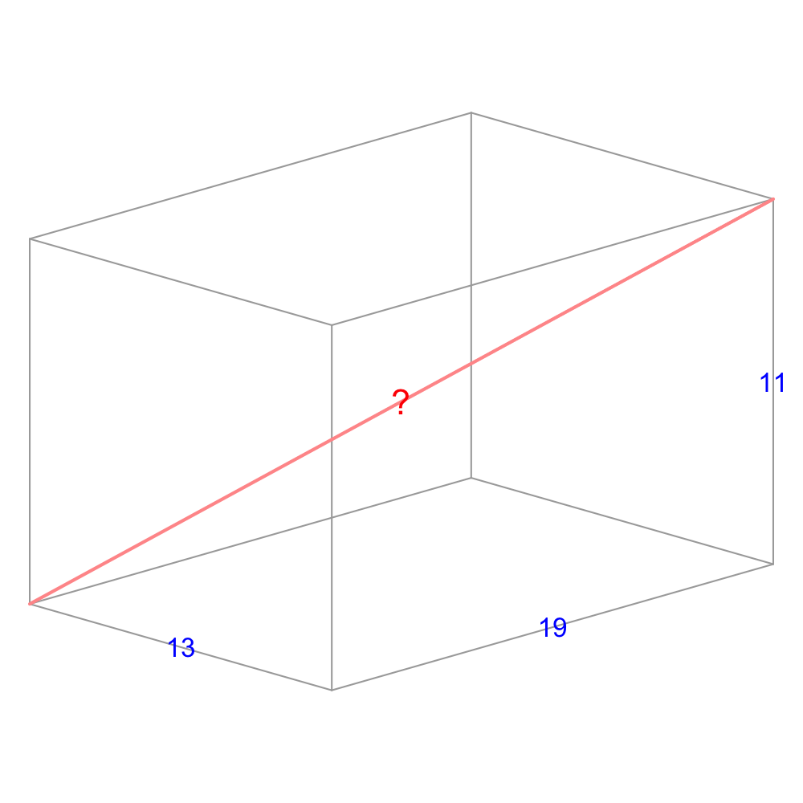

Please be accurate within $\pm$ 0.01 of the exact answer.

Let's use Pythagorean Theorem. This is possible because all angles are 90 degrees. To do this, we can first find the length of a diagonal across the bottom. Let's call it $B$.

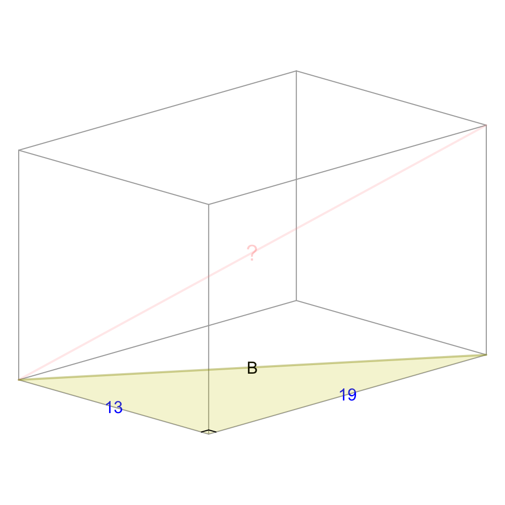

$$B~=~\sqrt{19^2+13^2}~=~\sqrt{530}
~\approx~23.0217289$$

Now we can form another **right triangle**, using $B$, the height, and the desired length, which we can call $D$.

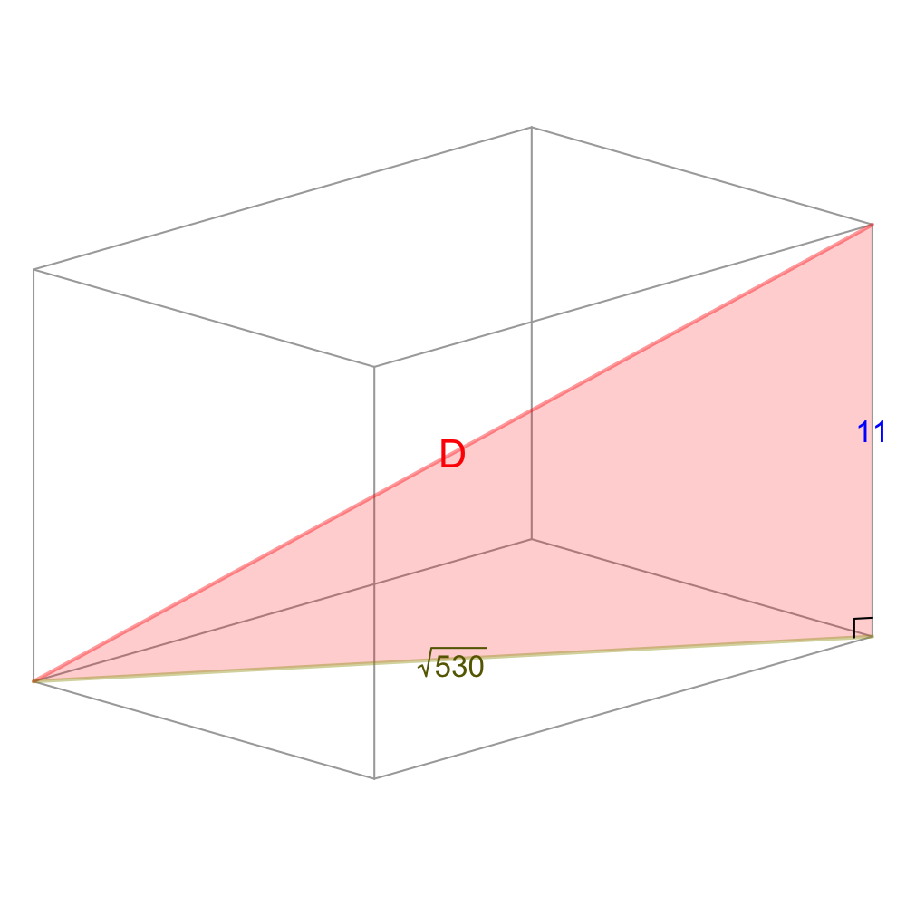

$$D ~=~
\sqrt{11^2+\left(\sqrt{530}\right)^2}$$
$$D ~=~ \sqrt{121+530}$$
$$D ~=~ \sqrt{651}$$
$$D ~\approx~ 25.5147016$$

If you were super observant, you might have picked up on a shortcut. Basically, in 3D, [the distance](https://en.wikipedia.org/wiki/Distance#Straight-line_or_Euclidean_distance) between 2 points is:

$$D~=~\sqrt{(\Delta x)^2+(\Delta
y)^2+(\Delta z)^2}$$

where $\Delta x=x_2-x_1$ and $\Delta y=y_2-y_1$ and $\Delta z=z_2-z_1$.

A [right rectangular prism](https://en.m.wikipedia.org/wiki/Rectangular_cuboid) is 20 inches wide, 18 inches deep, and 17 inches tall.

What is the distance between opposite corners?

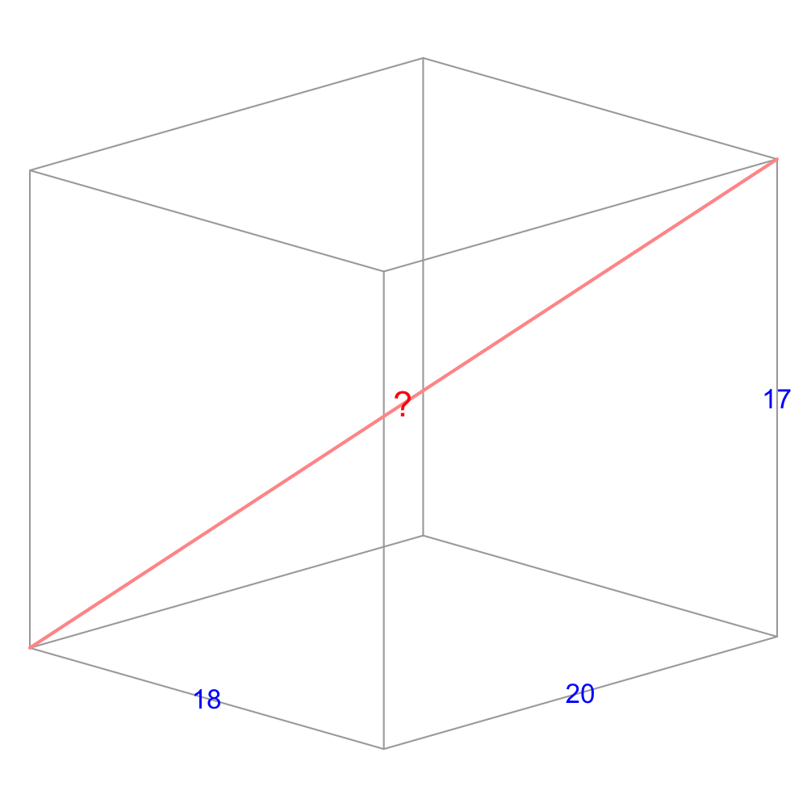

Please be accurate within $\pm$ 0.01 of the exact answer.

Let's use Pythagorean Theorem. This is possible because all angles are 90 degrees. To do this, we can first find the length of a diagonal across the bottom. Let's call it $B$.

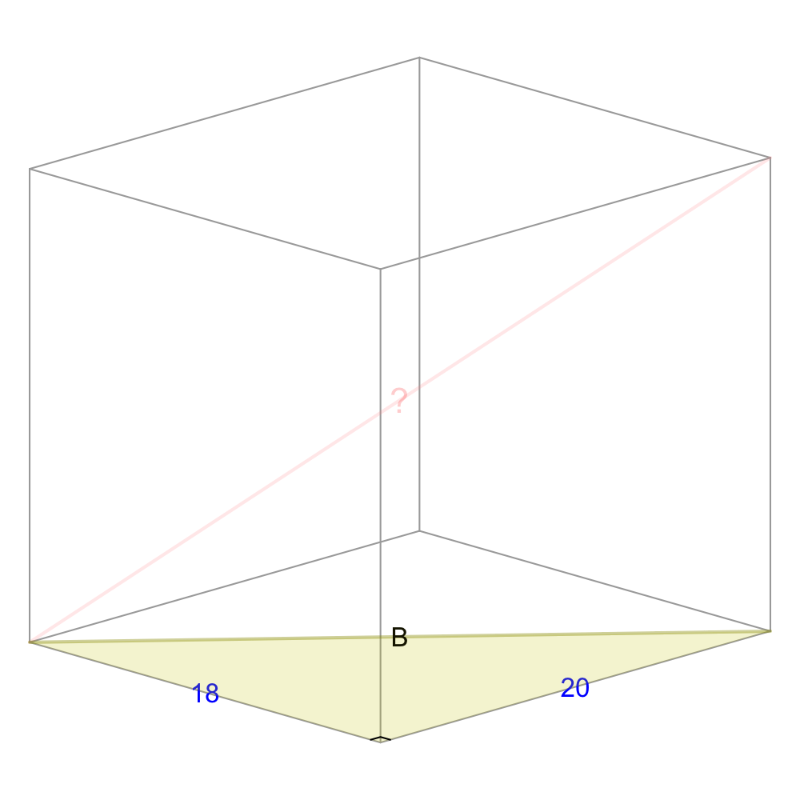

$$B~=~\sqrt{20^2+18^2}~=~\sqrt{724}
~\approx~26.9072481$$

Now we can form another **right triangle**, using $B$, the height, and the desired length, which we can call $D$.

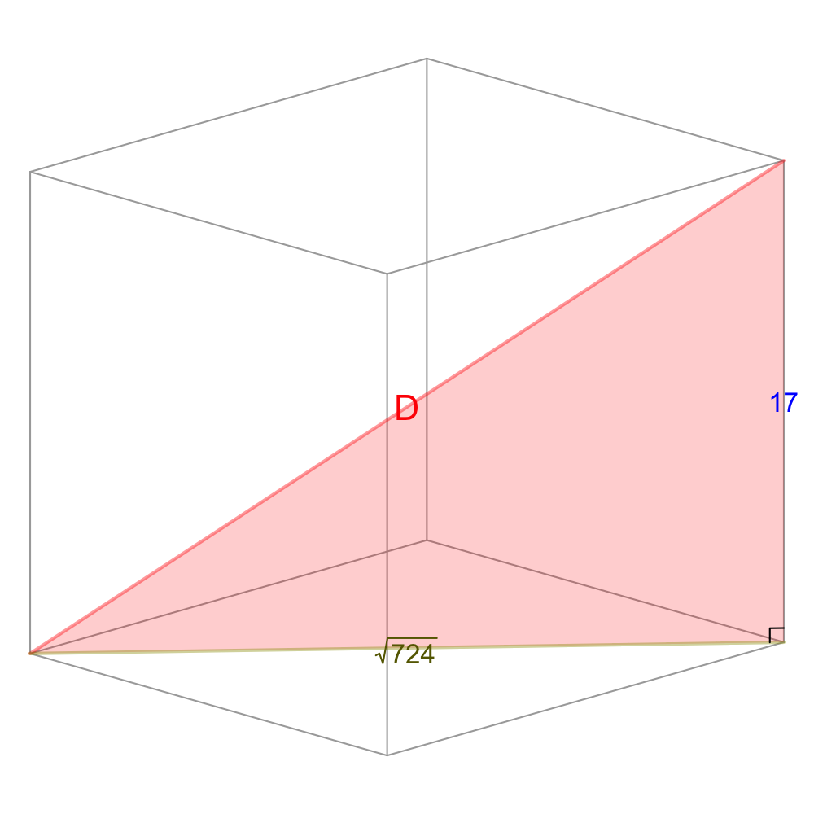

$$D ~=~
\sqrt{17^2+\left(\sqrt{724}\right)^2}$$
$$D ~=~ \sqrt{289+724}$$
$$D ~=~ \sqrt{1013}$$
$$D ~\approx~ 31.8276609$$

If you were super observant, you might have picked up on a shortcut. Basically, in 3D, [the distance](https://en.wikipedia.org/wiki/Distance#Straight-line_or_Euclidean_distance) between 2 points is:

$$D~=~\sqrt{(\Delta x)^2+(\Delta
y)^2+(\Delta z)^2}$$

where $\Delta x=x_2-x_1$ and $\Delta y=y_2-y_1$ and $\Delta z=z_2-z_1$.

A [right rectangular prism](https://en.m.wikipedia.org/wiki/Rectangular_cuboid) is 6 inches wide, 12 inches deep, and 7 inches tall.

What is the distance between opposite corners?

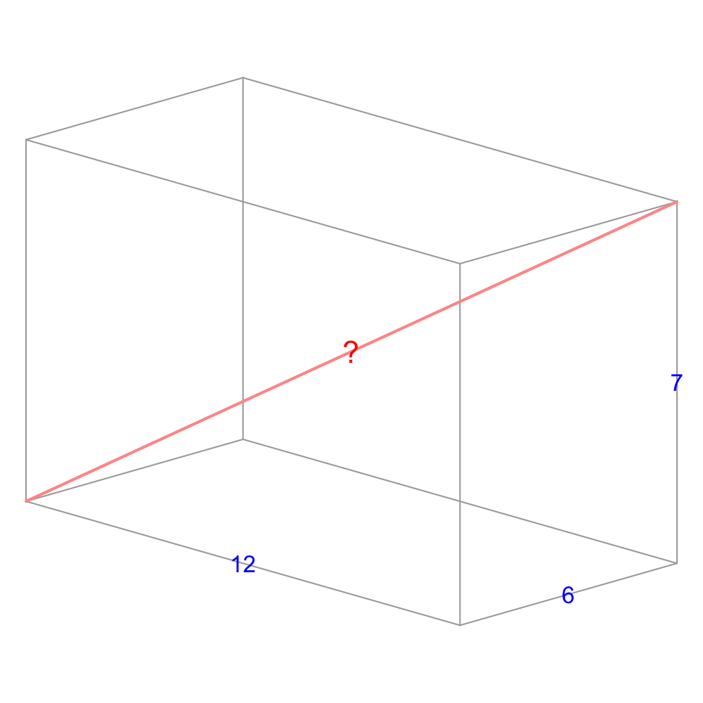

Please be accurate within $\pm$ 0.01 of the exact answer.

Let's use Pythagorean Theorem. This is possible because all angles are 90 degrees. To do this, we can first find the length of a diagonal across the bottom. Let's call it $B$.

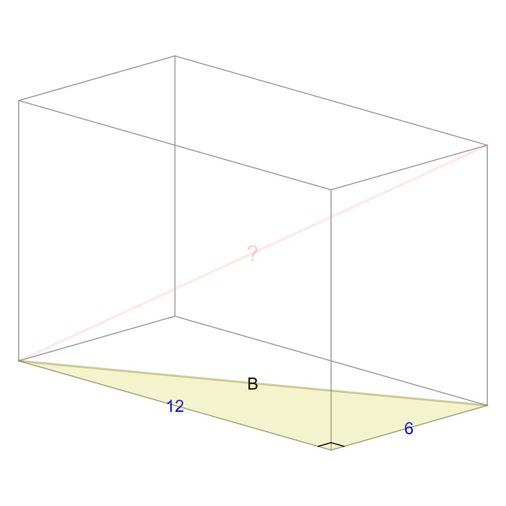

$$B~=~\sqrt{6^2+12^2}~=~\sqrt{180}
~\approx~13.4164079$$

Now we can form another **right triangle**, using $B$, the height, and the desired length, which we can call $D$.

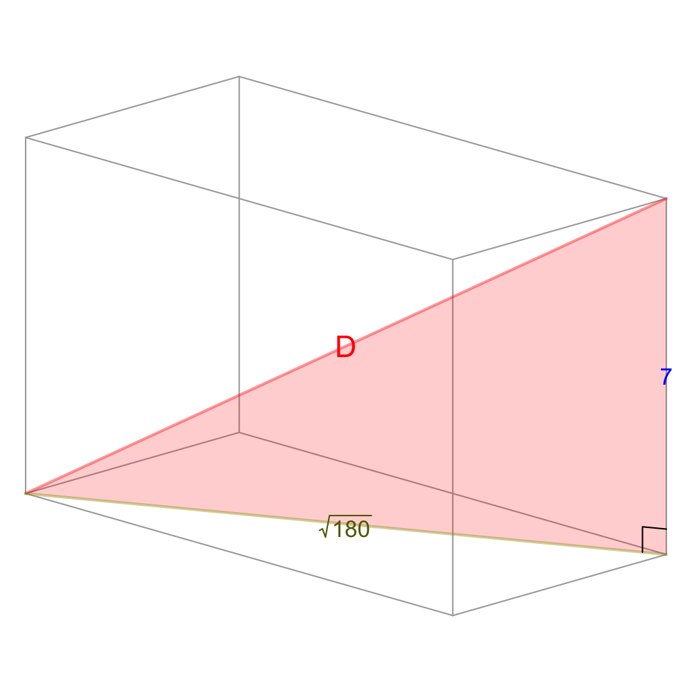

$$D ~=~
\sqrt{7^2+\left(\sqrt{180}\right)^2}$$
$$D ~=~ \sqrt{49+180}$$
$$D ~=~ \sqrt{229}$$
$$D ~\approx~ 15.132746$$

If you were super observant, you might have picked up on a shortcut. Basically, in 3D, [the distance](https://en.wikipedia.org/wiki/Distance#Straight-line_or_Euclidean_distance) between 2 points is:

$$D~=~\sqrt{(\Delta x)^2+(\Delta
y)^2+(\Delta z)^2}$$

where $\Delta x=x_2-x_1$ and $\Delta y=y_2-y_1$ and $\Delta z=z_2-z_1$.

A [right rectangular prism](https://en.m.wikipedia.org/wiki/Rectangular_cuboid) is 18 inches wide, 20 inches deep, and 5 inches tall.

What is the distance between opposite corners?

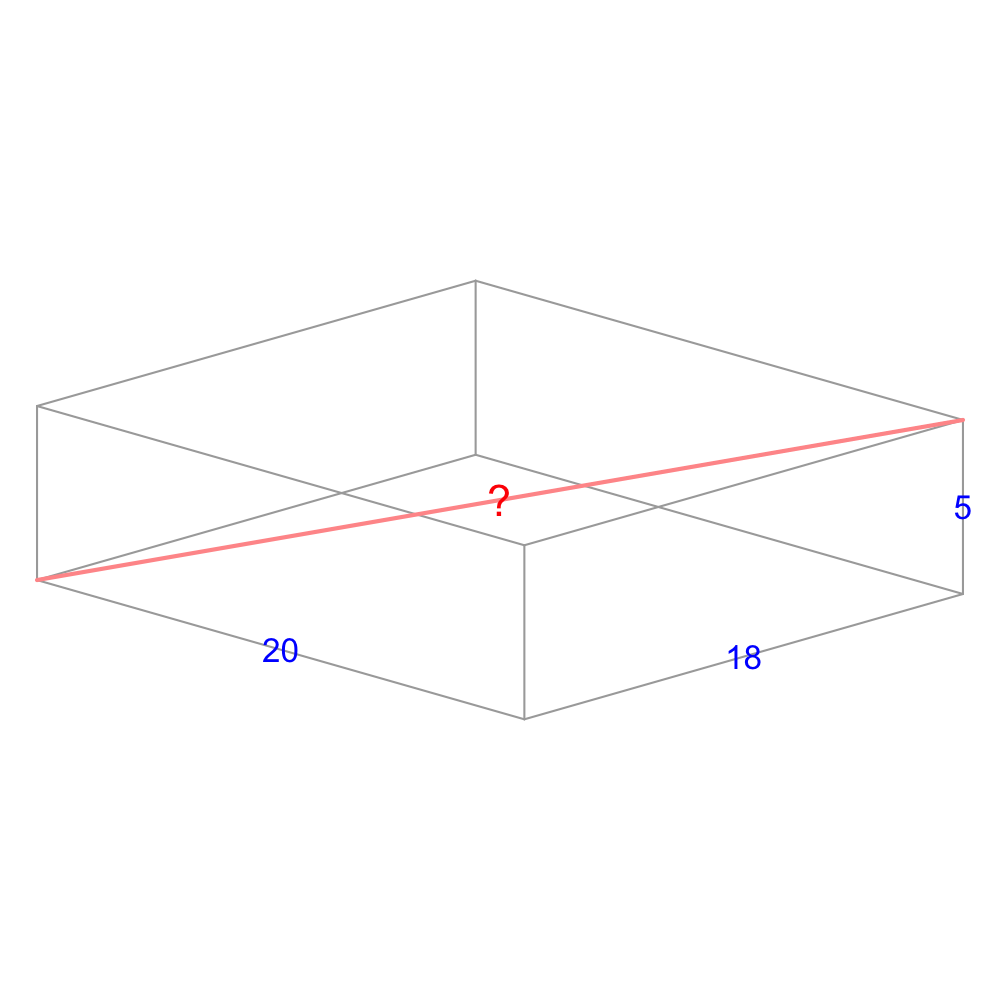

Please be accurate within $\pm$ 0.01 of the exact answer.

Let's use Pythagorean Theorem. This is possible because all angles are 90 degrees. To do this, we can first find the length of a diagonal across the bottom. Let's call it $B$.

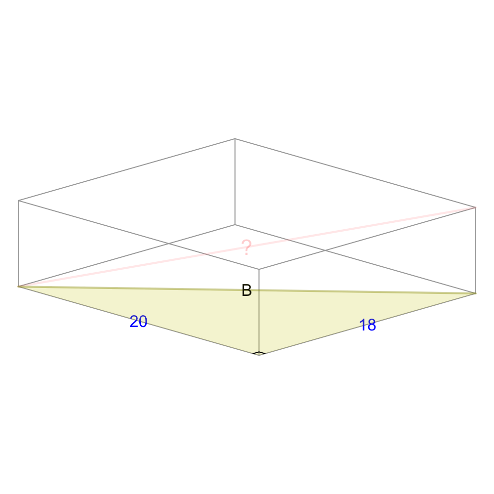

$$B~=~\sqrt{18^2+20^2}~=~\sqrt{724}
~\approx~26.9072481$$